# 자연언어처리 9주차_기계학습을 사용한 자연언어처리 #1: 지도학습(Naive Bayse, SVM)

고려대학교 일반대학원 심리학과

2025년 10월 27일 월요일 4-5교시

# 1. 지도학습(나이브 베이즈 및 서포트 벡터 머신)의 이론적 설명

## 본 수업에 사용될 함수 미리보기

- 수업목표와 직접적으로 관련된 함수는 본문에서 상세히 소개.
- 함수의 상세한 사용법은 코드 주석 참조.

**[표 1] 본 수업에 사용될 함수 목록**

| 함수 | 출처 패키지 | 역할 | 주요 논항 및 예시 |
| --- | --- | --- | --- |
| fromJSON() | jsonlite | JSON 파일을 읽어 R의 리스트나 데이터프레임으로 변환 | fromJSON(“파일경로.json”) |
| use_condaenv() | reticulate | R 세션에서 사용할 파이썬 아나콘다 가상환경 지정 | use_condaenv(“가상환경 이름”) |
| import() | reticulate | 지정된 파이썬 모듈을 R로 불러와 R 객체처럼 사용 | kiwi <- import(“kiwipiepy”) |
| corpus() | quanteda | 텍스트 데이터와 메타데이터를 말뭉치(corpus) 객체로 변환 | corpus(데이터, text_field = “텍스트열”, docvars = 메타데이터) |
| tokens() | quanteda | 말뭉치나 문자형 벡터를 단어 등 단위로 토큰화 | tokens(말뭉치, what = “word”) |
| tokens_custom() | quanteda | 사용자 정의 함수를 적용해 특수 토큰화(예: 형태소 분석)에 사용 | tokens_custom(토큰 객체, tokenizer = 사용자 정의 함수) |
| dfm() | quanteda | 토큰화 결과를 문서-단어 행렬(DFM)로 변환 | dfm(토큰 객체) |
| dfm_trim() | quanteda | DFM에서 너무 드문/너무 잦은 feature 제거로 차원 축소 | dfm_trim(dfm객체, min_docfreq = 2) # 최소 2개 문서 이상 등장 단어 유지 |
| createDataPartition() | caret | 클래스 비율 유지하면서 학습/테스트 분할 인덱스 생성 | createDataPartition(종속변수, p = 0.7, list = FALSE) # 70퍼센트 학습 |
| trainControl() | caret | train()의 학습 제어 설정(교차검증 등) | trainControl(method = “cv”, number = 10) # 10-fold CV |
| train() | caret | 지정 알고리즘과 trControl로 기계학습 모델 훈련 | train(x = 독립변수, y = 종속변수, method = “모델 이름”, trControl = 설정 객체) |
| predict() | Base R | 훈련된 모델로 새로운 데이터 예측 | predict(모델객체, newdata = 테스트 데이터) |
| confusionMatrix() | caret | 예측과 실제를 비교해 혼동행렬 및 성능 지표 산출 | confusionMatrix(예측값, 실제정답, positive = “긍정 클래스 이름”) |
| pivot_longer() | tidyverse(tidyr) | 넓은 형태 데이터를 긴 형태로 변환(ggplot2용 reshape) | pivot_longer(데이터, cols = -기준열, names_to = “변수명”, values_to = “값”) |
| ggplot() | tidyverse(ggplot2) | 데이터 시각화의 기본 틀 생성 및 aesthetic 연결 | ggplot(데이터, aes(x = x축 변수, y = y축 변수, fill = 그룹 변수)) |

## (1) 수업 목표 및 개요

- 수업목표:
  - 지도학습(supervised learning) 모델링 기법의 일종인 나이브 베이즈(Naive Bayes)와 서포트 벡터 머신(Support Vector Machine, SVM)의 핵심원리를 이해한다.
  - R의 **caret** 패키지를 활용하여 지도학습 모델링의 전 과정을 실습한다.
  - 혼동행렬(confusion matrix)을 기반으로 모델의 성능을 다각적으로 평가하고 해석하는 능력을 기른다.
- 수업개요:
  - 1부(이론)
    - 주요 모델(Naive Bayes, SVM) 원리 탐구.
    - 모델 성능 최적화를 위한 초매개변수 조정 개념 이해.
    - R 실습을 위한 **caret** 패키지 핵심 함수 및 논항 학습.
    - 모델 성능 평가 지표(정확도, 정밀도, 재현율, F1-Score) 학습.
  - 2부(실습)
    - 소비자 리뷰 데이터(AI 허브의 “속성기반 감정분석 데이터”)를 활용한 감성분류 모델링.
    - **kiwipiepy**를 이용한 한국어 텍스트 전처리(형태소 분석).
    - **quanteda**를 이용한 DFM 객체 생성.
    - **caret**을 이용한 나이브 베이즈, 서포트 벡터 머신 모델 훈련 및 교차검증.
    - **ggplot2**를 이용한 모델 성능 비교 시각화.

## (2) 텍스트 데이터와 문서-단어 행렬(DTM)

### 1) DTM의 한계와 중요성

- 텍스트 데이터의 수치화: 컴퓨터는 ‘텍스트’를 직접 이해할 수 없으므로, 수학적 연산이 가능한 ’숫자’ 형태로 변환해야 함.
- 문서-단어 행렬(Document-Term Matrix, DTM):
  - 텍스트 데이터를 행렬 형태로 표현하는 가장 대표적인 방법.
  - 행(row): 각 문서를 의미([EX] 리뷰 1, 리뷰 2, …)
  - 열(column): 전체 문서에 등장한 모든 고유 단어(Term)를 의미.
  - 값(value): 특정 문서(행)에 특정 단어(열)가 몇 번 등장했는지 빈도를 나타냄.
- DTM의 한계와 중요성:
  - 문맥이나 단어 순서 정보는 소실되지만(Bag-of-Words 가정), 어떤 단어가 어떤 문서에서 자주 나타나는지에 대한 핵심정보를 압축적으로 표현.
  - 기계학습 모델의 중요한 **입력(input) 데이터**로 사용됨.

### 2) DTM 가중치 부여 방식: 단어 빈도 vs. TF-IDF

- DTM의 각 셀에 어떤 값을 채워넣을지는 모델의 성능에 중요한 영향을 미침. 가장 대표적인 두 가지 방식은 ’단어 빈도’와 ’TF-IDF’임.
- 단어 빈도
  - 개념: DTM을 만드는 가장 간단하고 직관적인 방법으로, 각 문서에 특정 단어가 **등장한 횟수(count)**를 그대로 값으로 사용함.
  - 한계점: “그리고”, “있다”, “너무” 와 같이 여러 문서에 흔하게 등장하지만 실제 내용 파악에는 큰 도움이 되지 않는 단어들의 값이 커지는 문제가 있음. 이로 인해 모델이 문서의 핵심적인 특징을 파악하는 데 방해를 받을 수 있음.
- TF-IDF
  - 핵심 아이디어: 특정 문서 안에서는 자주 등장하지만(TF), 전체 문서들에서는 드물게 나타나는(IDF) 단어에 높은 가중치를 부여하는 방식임. 즉 **해당 문서를 다른 문서와 구별해주는 핵심 단어**의 중요도를 높여줌.
  - 장점:
    - 핵심단어 강조: 각 문서를 대표하는 핵심단어의 가중치를 자연스럽게 높여, 모델이 문서의 특징을 더 잘 학습하도록 도움.
    - 자동 불용어 처리 효과: 모든 문서에 자주 등장하는 단어들은 IDF 값이 매우 낮아져 가중치가 거의 0에 가까워지므로, 별도의 불용어 사전을 만들지 않아도 어느 정도 불용어를 거르는 효과를 가짐.
    - 모델 성능 향상
      - 일반적으로 단순 단어 빈도를 사용하는 것보다 TF-IDF 가중치를 사용했을 때 분류 모델의 성능이 더 높게 나타나는 경우가 많음.
      - 특정 문서에서 자주 등장하면서(TF가 높음) 다른 문서에서는 잘 등장하지 않는(IDF가 높음) 단어일수록 높은 TF-IDF 가중치를 갖게 됨. 이를 통해 모델은 각 문서를 더 잘 구별해내는 핵심 단어에 더 집중하게 됨.
  - 적용방법(**quanteda** 기준)
    - 기존과 동일하게 corpus 생성 $\rightarrow$ tokens 생성 $\rightarrow$ dfm 생성 $\rightarrow$ dfm_trim 과정을 거침.
    - 생성된 DFM에 `dfm_tfidf()` 함수를 적용하기만 하면 됨. 이 함수는 DFM의 각 셀 값을 단순 빈도에서 TF-IDF 가중치로 변환해줌.
    - 이후 과정은 동일함. **caret**의 `train()` 함수는 입력된 `data.frame`의 값이 정수(빈도)이든 실수(TF-IDF)이든 상관없이 모델을 훈련시킬 수 있음.
  - 모델별 특이사항
    - 서포트 벡터 머신: 서포트 벡터 머신은 데이터 포인터 간의 거리를 기반으로 최적의 경계선을 찾기 때문에, 단어의 중요도를 반영한 TF-IDF 가중치를 입력값으로 사용했을 때 성능이 향상되는 경우가 매우 많음.
    - 나이브 베이즈
      - 전통적인 나이브 베이즈는 단어의 등장 횟수(count)를 기반으로 확률을 계산하도록 설계되었음.
      - 하지만 **caret** 패키지에서 사용하는 `naive_bayes` 함수는 입력값이 연속형 실수(TF-IDF 값)일 경우, 커널 밀도 추정(kernel density estimation)과 같은 방식을 사용해 각 클래스에 대한 확률분포를 추정하므로 문제없이 적용 가능함.

### 3) 커널 밀도 추정(kernel density estimation, KDE)이란?

#### A. 시작: 히스토그램의 한계

- 우리가 어떤 데이터의 분포를 시각화할 때 가장 먼저 떠올리는 것이 **히스토그램**임.
- 히스토그램은 전체 데이터 범위를 몇 개의 구간(bin)으로 나눈 뒤, 각 구간에 데이터가 몇 개나 속하는지 막대 그래프로 보여줌. 매우 직관적이지만, 두 가지 단점이 존재.
  - 단점 1. 구간(bin) 설정에 따라 모양이 너무 달라짐: 구간을 너무 넓게 잡으면 데이터의 세밀한 분포를 놓치고, 너무 좁게 잡으면 분포가 울퉁불퉁해져 전체적인 모양을 파악하기 어려움.
  - 단점 2. 모양이 거칠고 불연속적임: 막대 그래프 형태라 부드러운 곡선이 아니어서, 특정 지점의 정확한 밀도(확률)를 추정하기 어려움.

#### B. 대안: 커널 밀도 추정

- 커널 밀도 추정은 이러한 히스토그램의 단점을 보완하여, 주어진 데이터만으로 부드러운 형태의 확률 밀도 함수(probability density function, PDF)를 추정하는 기법.
- 비유로 이해하기: “데이터 위에 부드러운 천 덮기”
  1. 수평선 위에 우리 데이터 포인트(TF-IDF 값들)가 점으로 찍혀 있다고 상상해보자.
  2. 각 데이터 포인트 **바로 위에**, 정규분포(종 모양)처럼 생긴 작은 **커널(kernel) 함수**를 하나씩 올려놓는다. 마치 각 점 위에 작은 모래 언덕을 하나씩 쌓는 것과 같다.
  3. 이 모든 작은 모래 언덕들을 전부 다 더한다. 그러면 점들이 촘촘히 모여있는 곳은 언덕이 높게 쌓이고, 점들이 듬성듬성 있는 곳은 언덕이 낮게 쌓일 것.
  4. 이렇게 합쳐진 전체 언덕의 모양이 바로 커널 밀도 추정으로 얻어진 확률 밀도 곡선임.

#### C. 나이브 베이즈와 TF-IDF에서 커널 밀도 추정이 하는 역할

- 전통적인 나이브 베이즈: “이 단어가 3번 나왔다”처럼 **정수 카운트** 데이터를 다룸.
- TF-IDF 데이터: “이 단어의 TF-IDF 값은 0.152이다”처럼 **연속적인 실수** 데이터임.
- **caret**의 `naive_bayes()` 함수는 TF-IDF와 같은 실수형 데이터가 입력으로 들어오면, 각 클래스(‘긍정’, ‘부정’)와 각 단어(feature)에 대해 이 커널 밀도 추정을 사용. $\Rightarrow$ “긍정 클래스에서 ‘가성비’라는 단어의 TF-IDF 값들은 대략 이런 분포(모양)를 보이는구나” 하고 학습하는 것. 그리고 새로운 데이터가 들어왔을 때, 그 데이터의 ’가성비’ TF-IDF 값이 긍정 클래스의 분포에서 나타날 확률과 부정 클래스의 분포에서 나타날 확률을 비교하여 분류를 수행하게 됨.
- 요약: 커널 밀도 추정은 나이브 베이즈 모델이 정수가 아닌 TF-IDF 같은 **연속적인 실수 값을 처리할 수 있도록, 데이터의 분포를 부드러운 확률곡선으로 추정해주는 통계적 도구**!

## (3) 지도학습 모델

- 지도학습 개념과 원리: 입력 데이터(특징 X)와 정답 레이블(y)이 짝지어진 데이터를 사용하여 함수나 규칙을 학습해 새로운 입력에 대해 정답을 예측하는 기계학습 방법.
- 주요 종류
  - 분류(classification): 레이블이 범주형([EX] 스팸/정상, 긍정/부정).
  - 회귀(regression): 레이블이 연속값([EX] 가격, 온도).
- 대표적 알고리즘
  - 단순 모델: 나이브 베이즈, 로지스틱 회귀, 선형회귀.
  - 복잡 모델: 서포트 벡터 머신, 의사결정나무, 랜덤포레스트, 신경망(딥 러닝).
- 장점과 한계
  - 장점: 명확한 성능평가와 자동화된 예측 가능. 다양한 알고리즘과 도구 존재.
  - 한계: 레이블이 필요하기 때문에 라벨링 비용이 들고, 레이블 편향이나 과적합에 민감함.
- 언제 쓰나?: 과거에 마련된 정답이 있는 문제에서 미래 또는 미관측 샘플의 레이블을 예측해야 할 때 사용.

### 2) 나이브 베이즈 분류기(naive Bayes classifier)

- 핵심 아이디어:특정 단어들이 주어졌을 때, 이 문서가 ’긍정’일 확률과 ’부정’일 확률을 **조건부 확률**을 이용해 계산하고, 더 높은 확률을 가진 범주로 문서를 분류하는 기법.
- 기반이론: 베이즈 정리(Bayes’ Theorem)
  - 두 확률변수의 사전확률과 사후확률 간 관계를 나타내는 정리.
  - 감성 분석 적용: $P(\text{긍정} | \text{단어들}) = \frac{P(\text{단어들} | \text{긍정}) \times P(\text{긍정})}{P(\text{단어들})}$
    - $P(\text{긍정} | \text{단어들})$: 사후확률. 어떤 문서에 특정 ’단어들’이 나타났을 때, 그 문서가 ’긍정’일 확률(우리가 최종적으로 구하고 싶은 값).
    - $P(\text{단어들} | \text{긍정})$: 가능도(Likelihood). ‘긍정’ 문서들 전체에서 특정 ’단어들’이 나타날 확률.
    - $P(\text{긍정})$: 사전확률. 전체 문서 중 ‘긍정’ 문서가 차지하는 비율.
    - $P(\text{단어들})$: 증거(Evidence). 전체 문서에서 특정 ’단어들’이 나타날 확률.
- **나이브(naive)** 가정의 의미:
  - ‘순진하다’, ’단순하다’는 의미.
  - 모델의 계산을 단순화하기 위해 **“모든 단어는 서로 독립적(independent)이다”**라고 과감하게 가정함.
  - 예시: “가격 저렴”이라는 텍스트에서 ’가격’이라는 단어의 등장과 ’저렴’이라는 단어의 등장은 서로 아무런 영향을 주지 않는 별개의 사건이라고 가정.
  - 현실: 실제로는 ‘가격’ 뒤에 ‘저렴하다’, ‘비싸다’ 등이 올 확률이 높으므로 이 가정은 틀렸음.
  - 효과: 하지만 이러한 ‘순진한’ 가정 덕분에 계산이 매우 빠르고 단순해지며, 그럼에도 불구하고 많은 텍스트 분류 문제에서 준수한 성능을 보임.
- 스팸 메일 분류 예시로 이해하기
  1. 데이터 준비: ‘스팸’ 메일 그룹과 ‘정상’ 메일 그룹을 준비.
  2. 확률 계산:
     - 각 그룹에서 “광고”, “당첨”, “무료” 같은 단어들이 얼마나 자주 등장하는지 확률($P(\text{단어} | \text{스팸})$, $P(\text{단어} | \text{정상})$을 미리 계산해둠.
  3. 새로운 메일 도착: “광고! 무료 당첨!”이라는 제목의 새 메일 도착.
  4. 확률 비교:
     - 스팸일 확률: $P(\text{스팸}) \times P(\text{광고} | \text{스팸}) \times P(\text{무료} | \text{스팸}) \times P(\text{당첨} | \text{스팸})$
     - 정상일 확률: $P(\text{정상}) \times P(\text{광고} | \text{정상}) \times P(\text{무료} | \text{정상}) \times P(\text{당첨} | \text{정상})$
     - 두 확률 값을 비교하여 더 큰 값으로 메일을 분류.
- 기술적 이슈: 제로 빈도 문제(zero-frequency problem)
  - 문제점: 훈련 데이터에 한 번도 등장하지 않은 단어가 테스트 데이터에 나타날 경우, 해당 단어의 조건부 확률이 0이 되어 전체 확률이 0으로 계산되는 문제.
  - 예시: 훈련 데이터의 ‘긍정’ 문서에는 ‘환상적’이라는 단어가 없었다면, $P(\text{환상적} | \text{긍정})=0$. 이 경우, “이 옷은 정말 환상적”이라는 문서는 ’환상적’ 단어 하나 때문에 긍정일 확률이 0이 되어버림.
  - 해결책: 라플라스 스무딩(Laplace smoothing)
    - 모든 단어의 빈도수에 아주 작은 값(보통 1)을 더해줘서, 한 번도 등장하지 않은 단어의 확률이 0이 되는 것을 방지하는 기법.
    - 분모에도 단어의 총 개수(vocabulary size)를 더해 전체 확률의 합이 1이 되도록 보정.

### 3) 서포트 벡터 머신(support vector machine, SVM)

- 핵심 아이디어:각 데이터들을 고차원 공간의 좌표(벡터)로 표현했을 때, 서로 다른 범주(긍정/부정)의 데이터들을 가장 잘 나눌 수 있는 **최적의 경계선(decision boundary)**을 찾는 기법.
- 주요 용어:
  - 결정경계(Decision Boundary): 데이터를 분류하는 기준선. 2차원에서는 ‘선’, 3차원에서는 ‘평면’, 그 이상의 고차원에서는 **‘초평면(hyperplane)’**이라고 부름.
  - 마진(margin): 결정경계와 각 범주의 가장 가까운 데이터 샘플(벡터) 사이의 거리. SVM은 이 **마진을 최대화(maximize)**하는 것을 목표로 함. 마진이 클수록 새로운 데이터에 대한 일반화 성능이 좋다고 봄.
  - 서포트 벡터(support vectors): 마진을 결정하는 데 영향을 주는, 즉 결정경계와 가장 가까이 위치한 데이터 샘플들. 이름 그대로 결정경계를 ‘떠받치는(support)’ 벡터들임. 이 서포트 벡터들만이 모델을 결정하며, 나머지 데이터들은 모델에 영향을 주지 않음.

**[그림 1] 2차원과 3차원 결정경계 예시**

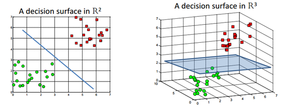

**[그림 2] 서포트 벡터의 예시**

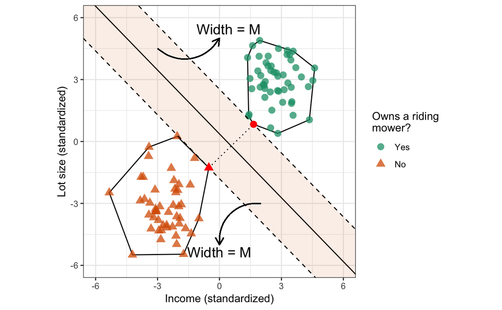

- 하드 마진(hard margin) vs. 소프트 마진(soft margin)
  - 하드 마진: 단 하나의 오분류도 허용하지 않고 데이터를 완벽하게 나누는 경계선을 찾는 방식. 데이터가 선형적으로 완벽하게 분리될 수 있을 때만 사용 가능하며, 이상치(outlier)에 매우 민감함.
  - 소프트 마진: 약간의 오분류나 마진 내 침범을 허용하여, 보다 유연하고 현실적인 경계선을 찾는 방식. 대부분의 실제 데이터 분석 상황에서 사용됨.
- 커널 트릭(kernel trick): 비선형 데이터 분류하기
  - 문제점: 현실의 텍스트 데이터는 ‘긍정’과 ’부정’ 단어들이 복잡하게 섞여 있어, 직선(선형) 하나로 완벽하게 나누기 어려운 경우가 많음.
  - 해결책:
    1. 현재 차원([EX] 2차원)에서 분리하기 힘든 데이터를 **커널 함수**를 이용해 더 높은 차원([EX] 3차원)으로 보냄.
    2. 고차원으로 이동된 데이터는 선형적으로 분리될 가능성이 높아짐. 여기서 최적의 경계면(초평면)을 찾음.
    3. 이 경계면을 원래의 저차원으로 다시 가져오면, 복잡한 곡선 형태의 결정 경계가 됨.
  - 장점
    - 실제로 데이터를 고차원으로 보내는 복잡한 계산을 하지 않고도, 커널 함수를 통해 고차원에서 계산한 것과 같은 효과를 얻을 수 있어 매우 효율적임(그래서 ’트릭’이라 불림).
    - 고차원 희소 데이터(텍스트 DFM)에서 강력한 성능을 보이는 경우가 많음.

**[그림 3] 커널 트릭으로 데이터를 분리하는 과정**

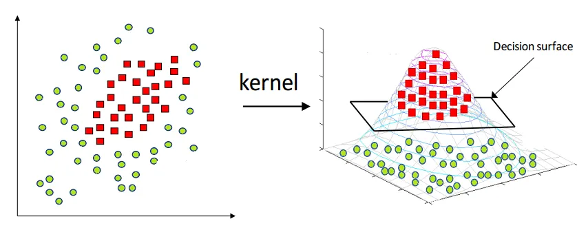

### 4) 초매개변수 조정(hyperparameter tuning)

- 핵심 아이디어:모델이 스스로 학습하는 값(매개변수)이 아니라, 분석가가 모델의 성능을 최적화하기 위해 **직접 설정해주는 외부 옵션 값(초매개변수)**을 찾는 과정.
- 비유로 이해하기: 모델 = 요리, 초매개변수 = 레시피
  - 모델([EX] SVM): ’김치찌개’라는 요리 자체.
  - 매개변수(Parameter): 끓이는 과정에서 자연스럽게 정해지는 값([EX] 끓으면서 변하는 국물의 염도, 온도). 모델이 훈련 데이터를 통해 **스스로 학습**하는 값.
  - 초매개변수(hyperparameter): 요리를 시작하기 전에 사람이 **미리 정하는 레시피**([EX] “소금 한 스푼, 설탕 반 스푼, 끓이는 시간 10분”). 이 레시피에 따라 김치찌개의 맛(모델의 성능)이 달라짐.

**[그림 4] 초매개변수 조정의 시각적 비유**

[figure not shown]

- 대표적인 조정 방법: 그리드 탐색(grid search)
  - 개념: 사용자가 초매개변수의 후보 값들을 미리 여러 개 지정하면, 가능한 모든 조합을 시도해보고 그 중 가장 성능이 좋은 조합을 선택하는 방식.
  - SVM 예시:
    - SVM의 대표적인 초매개변수는 C(cost) 값임(소프트 마진에서 얼마나 많은 오류를 허용할지에 대한 비용).
    - 사용자가 C의 후보 값으로 [0.1, 1, 10, 100]을 지정.
    - 그리드 탐색은 C=0.1일 때의 모델 성능, C=1일 때의 성능, …, C=100일 때의 성능을 **교차검증(cross-validation)**을 통해 모두 측정.
    - 측정한 성능 중 가장 높은 점수를 기록한 C 값을 최적의 초매개변수로 선택.
  - **caret**의 `train()` 함수는 내부적으로 기본적인 그리드 탐색 과정을 자동으로 수행하여 최적의 초매개변수를 찾아줌.

### 5) 모델의 일반화 성능 평가: 교차검증(cross-validation)

#### A. 교차검증의 필요성과 내부기제

- 도입: 왜 필요할까?
  - 데이터를 훈련용(train)과 테스트용(test)으로 딱 한 번만 나누면, 어떤 데이터가 테스트용으로 선택되었는지 ’운’에 따라 모델 성능이 실제보다 좋거나 나쁘게 나올 수 있음.
  - 비유: 모의고사를 단 한 번 봤는데, 우연히 아는 문제만 나와서 100점을 받은 경우, 그 점수가 진정한 수능 점수라고 확신하기 어려운 것과 같음.
- 핵심개념: 주어진 훈련 데이터를 여러 번 다른 방식으로 쪼개어, 여러 번의 훈련과 검증을 반복하고 그 성능의 평균을 내는 방법임. 이를 통해 특정 데이터 분할에 따른 성능 왜곡을 줄이고, 모델이 새로운 데이터에 대해 얼마나 잘 작동할지(일반화 성능)를 더 안정적으로 추정할 수 있음.
- *k*-겹 교차검증(*k*-fold cross-validation) 과정:
  - 가장 널리 사용되는 교차검증 방식임. 아래는 *k* = 5인 경우의 과정 예시임.

**[그림 5] 교차검증 방식 예시(*k* = 5)**

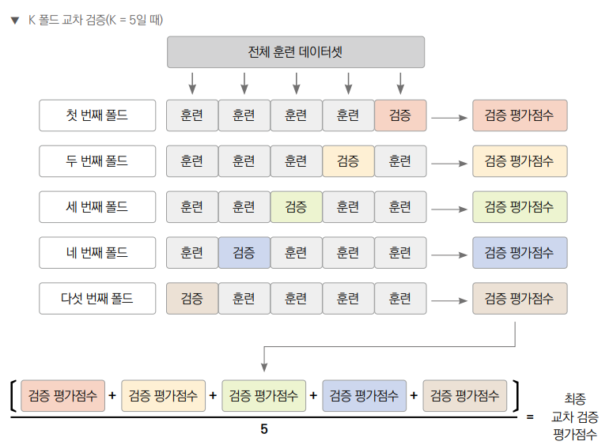

1. 분할(split): 전체 훈련 데이터를 비슷한 크기의 *k* 개 그룹(폴드[fold])으로 나눔(위 예시에서는 5개).
2. 반복 훈련 및 검증
   - 첫 번째 반복: 1번 폴드를 ’검증(validation) 데이터’로, 나머지 *k*-1 개 폴드를 ’훈련 데이터’로 사용함. 모델을 훈련하고 검증 데이터로 성능을 측정함.
   - 두 번째 반복: 2번 폴드를 검증 데이터로, 나머지 폴드들을 훈련 데이터로 사용함. 다시 모델을 훈련하고 성능을 측정함.
   - … 이 과정을 *k* 번 반복하여, 모든 폴드가 정확히 한 번씩 검증 데이터로 사용되도록 함.
3. 성능 종합(average): *k* 번 반복해서 얻은 *k* 개의 성능 점수([EX] 정확도)를 **평균**내어, 모델의 최종 성능으로 간주함.
- 장점
  - 모델의 성능을 더 안정적이고 신뢰성 있게 평가할 수 있음.
  - 모든 데이터를 훈련과 검증에 한 번씩은 사용하게 되므로 데이터 활용도가 높음.

#### B. 교차검증의 부작용(?)

- 훈련용 데이터셋으로 기계학습을 시행한 후 다음과 같은 경고 메시지가 종종 나오곤 함. 이 경고 메시지는 **caret** 패키지가 모델을 훈련하는 내부과정과 관련이 있음.

```r
nb_model <- train(
  x = train_x,               # x = train_x: 독립변수(TF-IDF 정보가 담긴 데이터프레임).
  y = train_y,               # y = train_y: 종속변수(감성[긍정 vs. 부정] 레이블).
  method = "naive_bayes",    # method = "naive_bayes": 사용할 모델 알고리즘으로 나이브 베이즈 지정.
  trControl = ctrl_imbalance # 업샘플링 등이 적용된 콘트롤 설정 사용.
)

41건의 경고들이 발견되었음 (이를 확인하기 위해서는 warnings()를 이용하시길 바랍니다).
Warning messages:
1: predict.naive_bayes(): more features in the newdata are provided as there are probability tables in the object. Calculation is performed based on features to be found in the tables.
......
```

- 경고 메시지의 의미: “검증 데이터셋(newdata)에 훈련 때 보지 못했던 새로운 단어들이 있음. 나이브 베이즈 모델은 이 새로운 단어들은 무시하고, 훈련 때 학습했던 단어들만을 사용하여 예측확률을 계산했음.”
- 의문: `train()` 함수 자체에는 **오직 훈련 데이터**(`train_x`, `train_y`)**만** 들어갔는데, 어떻게 모델이 테스트 데이터(`test_x`)에나 있을 법한 “새로운 단어(features in the newdata)”를 만났다고 경고하는 것일까? $\Rightarrow$ 핵심은 `trainControl()` 함수에 설정한 교차검증(`method = "cv"`) 때문!
- 경고 이유
  - `train()` 함수는 단순히 `train_x` 전체를 한 번에 학습하는 것이 아니라, 내부적으로 다음과 같은 **교차검증 과정**을 수행함.
    - 1. 내부분할: `train()` 함수는 전달받은 훈련 데이터(`train_x`, `train_y`)를 `trainControl`에서 지정한 `number`(여기서는 10개) 만큼의 그룹(fold)으로 **내부적으로 다시 나눔.**
    - 2. 반복 훈련 및 검증
      - 첫 번째 반복: 1번 그룹을 내부 검증용(internal validation set)으로 사용하고, 나머지 9개 그룹을 내부 훈련용(internal training set)으로 사용하여 나이브 베이즈 모델을 **임시로** 훈련. 그리고 이 임시 모델로 1번 그룹 데이터를 예측(predict)하여 성능을 평가함.
      - 두 번째 반복: 2번 그룹을 내부 검증용으로, 나머지 그룹을 내부 훈련용으로 사용하여 다시 임시 모델을 훈련하고 예측함.
      - … 이 과정을 총 10번 반복.
    - 3. 최종 모델 훈련: 교차검증을 통해 얻은 성능정보를 바탕으로, **전체 훈련 데이터**(`train_x`, `train_y`)를 사용하여 최종 모델(`nb_model`)을 생성함.
  - 경고 메시지가 발생하는 시점은 바로 위의 2단계, 즉 내부 교차검증 과정에서 임시 모델이 내부 검증용 데이터를 예측할 때임!
- 종합
  - 내부적으로 데이터를 나누다 보면, **특정 내부 검증용 그룹(newdata)**에는 존재하지만, 그것을 제외한 나머지 **내부 훈련용 그룹(object)**에는 존재하지 않았던 단어(feature)가 있을 수 있음.
  - 이때 `predict.naive_bayes()` 함수는 “어? 내가 훈련할 땐 못 봤던 단어가 검증 데이터에 있네?”라고 인식하고, “이 단어는 무시하고 내가 아는 단어들로만 계산할게!”라고 알려주는 것.
  - 이 경고 메시지는 최종 모델(`nb_model`)이 외부 테스트 데이터(`test_x`)를 예측할 때 발생한 것이 아니라, 모델을 만드는 과정 중 내부 교차검증 단계에서 발생한 것!
  - 이 경고는 매우 흔하며, 내부 데이터 분할 과정 때문에 나타날 수 있음. 최종 모델의 성능 평가에는 직접적인 영향을 주지 않는 경우가 대부분이므로 크게 걱정하지 않아도 됨.

## (4) 기계학습을 위한 핵심도구: **caret** 패키지

- **caret**(Classification And REgression Training): 다양한 기계학습 모델을 일관된 인터페이스로 훈련하고 평가할 수 있게 해주는 R 패키지.

### 1) `trainControl()` 함수: 훈련과정 통제

- 역할: `train()` 함수가 모델을 어떻게 훈련하고 검증할지에 대한 ’설정값’들을 정의하는 함수. 말하자면, 모델 훈련의 ’레시피’를 만드는 과정.
- 주요 논항:
  - `method`: 훈련 데이터의 성능을 평가하는 방법 지정
    - `cv`(cross-validation): 데이터를 *k*개의 그룹(fold)으로 나누어, *k*-1개로 훈련하고 1개로 검증하는 과정을 *k*번 반복. 가장 일반적인 교차검증 방식.
    - `repeatedcv`(repeated cross-validation): `cv`를 여러 번 반복하여 더 안정적인 성능 추정치를 얻음. `repeats` 논항으로 반복 횟수 지정.
    - `boot`(bootstrapping): 중복을 허용하여 원본 데이터와 같은 크기의 표본을 여러 번 추출하여 성능을 평가.
  - `number`: `method=cv`일 때, 데이터를 몇 개의 그룹(fold)으로 나눌지 지정([EX] `number=10` $\Rightarrow$ 10-fold cross-validation).
  - `summaryFunction`: 모델 성능을 평가할 지표를 지정하는 함수([EX] `twoClassSummary`는 정확도 외에 ROC(receiver operating characteristic)[^1], 민감도, 특이도 등을 계산).
  - `classProbs`: 각 클래스(긍정/부정)에 속할 ’확률’을 계산할지 여부(`TRUE`/`FALSE`). ROC 곡선을 그리거나 확률 기반 평가를 할 때 필요.
- 구체적인 예시 코드:
  - 10-fold 교차검증을 수행하고, 각 클래스별 확률을 계산하도록 설정.
  - `multiClassSummary`를 사용하면 `Accuracy`, `Kappa`, `F1`, `Precision`, `Recall` 등을 한 번에 볼 수 있음.

```r
ctrl <- trainControl(method = "cv",
                     number = 10,
                     summaryFunction = multiClassSummary,
                     classProbs = TRUE)
```

### 2) `train()` 함수: 모델 훈련 실행

#### A. 주요 논항

- 역할: `trainControl()`로 정의된 설정에 따라, 지정된 데이터를 사용하여 특정 기계학습 모델을 훈련시키는 핵심 함수.
- 주요 논항:
  - `form` 또는 `x`, `y`: 모델의 종속변수와 독립변수를 지정.
    - `sentiment ~ .` : sentiment가 종속변수이고, 데이터의 나머지 모든 변수(.)가 독립변수임을 의미.
  - `data`: 훈련에 사용할 데이터프레임.
  - `method`: 훈련시킬 기계학습 모델의 종류를 지정하는 문자열.
    - `naive_bayes`: 나이브 베이즈 모델.
    - `svmLinear`: 선형 커널을 사용하는 서포트 벡터 머신.
    - `rf`: 랜덤 포레스트.
    - 사용 가능한 모델 목록은 `names(getModelInfo())` 명령어로 확인 가능.
  - `trControl`: `trainControl()` 함수로 생성한 훈련설정 객체를 전달.
  - `tuneGrid`
    - 개념: 초매개변수 조정을 위해 시도할 값들의 조합을 데이터프레임 형태로 직접 지정. 이 논항을 생략하면 **caret**이 자동으로 몇 개의 기본값을 실험해봄. 간단한 모델에서는 괜찮지만, 최적의 성능을 찾기 위해서는 `tuneGrid`를 통해 더 넓은 범위의 값을 탐색하는 것이 좋음.
    - **caret** 패키지의 `train()` 함수는 모델 훈련 시 초매개변수 튜닝을 자동으로 수행하는 강력한 기능을 제공. 이때 `tuneGrid` 논항은 어떤 초매개변수 값들의 조합을 실험해볼지 사용자가 직접 지정할 때 사용됨.
    - 역할: `train()` 함수에게 그리드 탐색(Grid Search)을 수행할 초매개변수 값들의 목록 전달.
    - 형식: 데이터프레임(data.frame) 또는 tibble 형태여야 함.
      - 데이터프레임의 **열 이름**: 튜닝하려는 모델의 초매개변수 이름과 정확히 일치해야 함(어떤 초매개변수를 튜닝할 수 있는지는 `modelLookup`(“모델 이름”) 명령어로 확인 가능).
      - 데이터프레임의 **각 행**은 테스트할 초매개변수 값들의 한 조합을 나타냄.
    - `expand.grid()` 함수 활용: 여러 초매개변수의 다양한 값 조합을 쉽게 만들기 위해 expand.grid() 함수가 자주 사용됨. 이 함수는 각 초매개변수에 대한 후보 값 벡터들을 입력받아, 가능한 모든 조합을 포함하는 데이터프레임을 생성.

#### B. 초매개변수 예시

##### 가. 나이브 베이즈 모델 튜닝

- 사용 패키지: **naivebayes** 패키지.
- 주요 초매개변수
  - `modelLookup("naive_bayes")`를 실행하면, `naive_bayes` 모델은 `laplace`, `usekernel`, `adjust`라는 세 가지 초매개변수를 튜닝할 수 있음을 알 수 있음.
  - `laplace`: 라플라스 스무딩(Laplace smoothing) 값. 0 빈도 문제를 완화하며, 기본값은 0. 이 값을 증가시키면([EX] 1), 드문 단어의 영향력을 줄여 모델의 일반화 성능을 높일 수 있음.
  - `usekernel`: 입력 데이터(DTM 값)가 연속형 실수([EX] TF-IDF 사용 시)일 경우, 커널 밀도 추정을 사용할지 여부. 기본값은 `TRUE`이며, TF-IDF에는 `TRUE`가 적합. `FALSE`로 변경하면 다른 방식으로 처리.
  - `adjust`: `usekernel = TRUE`일 때, 커널 밀도 추정의 대역폭(bandwidth)을 조정하는 값. 기본값은 1이며, 값을 조절하여 분포추정의 부드러움을 변경할 수 있음(보통 0.5 ~ 1.5 사이 값 시도).
- 방법: `expand.grid()` 함수에 튜닝할 초매개변수 후보 값을 지정하여 넣은 후 `tuneGrid` 논항에 할당함.

```r
# 1. 튜닝할 초매개변수 후보 값 지정
laplace_values <- c(0, 1, 5)       # 라플라스 스무딩 값 후보.
usekernel_values <- TRUE           # TF-IDF 사용 시 TRUE 고정.
adjust_values <- c(0.5, 1.0, 1.5)  # 커널 밀도 추정 대역폭 후보.

# 2. expand.grid()로 모든 조합 생성
# 총 3 * 1 * 3 = 9가지 조합이 생성됨.
nb_grid <- expand.grid(
  laplace = laplace_values,
  usekernel = usekernel_values,
  adjust = adjust_values
)

# 생성된 그리드 확인(9행 3열 데이터프레임)
nb_grid
#   laplace usekernel adjust
# 1       0      TRUE    0.5
# 2       1      TRUE    0.5
# 3       5      TRUE    0.5
# 4       0      TRUE    1.0
# 5       1      TRUE    1.0
# 6       5      TRUE    1.0
# 7       0      TRUE    1.5
# 8       1      TRUE    1.5
# 9       5      TRUE    1.5

# 3. train() 함수에 tuneGrid 전달
set.seed(123)
nb_model_tuned <- train(
  x = train_x,
  y = train_y,
  method = "naive_bayes",
  trControl = ctrl_imbalance, # 교차검증 및 샘플링 설정.
  tuneGrid = nb_grid          # 사용자가 직접 설정한 초매개변수 조합 그리드 전달.
)

# 결과 확인
# train() 함수는 nb_grid의 9가지 조합 각각에 대해 교차검증을 수행.
# 가장 좋은 성능(e.g., Accuracy 또는 Kappa)을 보인 조합을 찾음.
# 그 조합으로 전체 훈련 데이터에 대해 최종 모델을 학습시킴.
# 출력 결과에서 어떤 조합이 최적이었는지 확인할 수 있음.
nb_model_tuned
```

##### 나. 서포트 벡터 머신 모델 튜닝

- 사용 패키지: **e1071** 패키지.
- 주요 초매개변수
  - `modelLookup("svmLinear")`를 실행하면, `svmLinear` 모델은 `C`(Cost)라는 한 가지 초매개변수를 튜닝할 수 있음을 알 수 있음.
  - `C`(Cost): 모델이 마진(margin)을 최대화하는 것과 훈련 데이터의 오류(오분류)를 최소화하는 것 사이에서 얼마나 균형을 맞출지를 조절.
    - 작은 C 값: 오류를 어느 정도 허용하더라도 마진을 넓게 가져가고자 함(부드러운 경계선, underfitting 위험).
    - 큰 C 값: 오류를 최소화하기 위해 마진이 좁아지더라도 데이터를 더 정확하게 나누고자 함(복잡한 경계선, overfitting 위험).
- `expand.grid()` 함수에 튜닝할 초매개변수 후보 값을 지정하여 넣은 후 `tuneGrid` 논항에 할당함. 튜닝할 초매개변수가 하나뿐이지만 나이브 베이즈와 동일한 방식 사용.
- 주의사항: 나이브 베이즈와 비교할 수 없을 만큼 시간이 매우 매우 오래 걸리므로, 초매개변수 튜닝 없이 쓸만한 결과를 얻었다면 사용을 보류할 것을 추천.

```r
# 1. 튜닝할 C 값 후보 지정
# 보통 10의 거듭제곱 형태나 그 사이 값들을 사용.
cost_values <- c(0.1, 0.5, 1, 5, 10)

# 2. expand.grid()로 모든 조합 생성(튜닝할 파라미터가 하나여도 나이브 베이즈와 동일 방식 사용)
# 열 이름 'C'는 modelLookup("svmLinear")에서 확인한 초매개변수 이름과 일치해야 함.
svm_grid <- expand.grid(C = cost_values)

# 생성된 그리드 확인
svm_grid
#      C
# 1  0.1
# 2  0.5
# 3  1.0
# 4  5.0
# 5 10.0

# 3. train() 함수에 tuneGrid 전달
set.seed(123)
svm_model_tuned <- train(
  x = train_x, y = train_y,
  method = "svmLinear",
  trControl = ctrl_imbalance, # 교차검증 및 샘플링 설정.
  tuneGrid = svm_grid         # 생성한 C 값 그리드 전달.
)

# 결과확인: 가장 좋은 성능을 보인 C 값 및 해당 성능 출력.
svm_model_tuned
```

### 3) `createDataPartition()` 함수: 데이터 분할

- 역할: 종속변수(y)의 분포(특히 범주형 클래스 비율)를 유지하면서 훈련용/테스트용 인덱스를 생성하는 **caret** 패키지 함수.
- 주요 논항
  - `y`: 분할을 기준으로 할 벡터(보통 종속변수). 범주형(팩터/문자)이면 각 클래스 비율을 유지하면서 샘플링함.
  - `times`: 생성할 분할(샘플) 개수. [EX] times = 3이면 동일한 설정으로 3개의 서로 다른 훈련용 인덱스 리스트를 반환.
  - `p`: 각 분할에서 뽑아낼 비율(훈련 데이터 비율). [EX] p = 0.7이면 전체의 70퍼센트를 뽑아 훈련용 인덱스로 반환.
  - `list`: `TRUE`(기본값)면 결과를 리스트로 반환. `FALSE`면 벡터(단일분할일 때) 또는 행렬(다중분할일 때) 형태로 받을 수 있음.
  - `groups`: 값 예시 $\Rightarrow$ `min(5, length(y))`. y가 연속형일 때 내부적으로 구간을 몇 개로 나눌지 지정. 범주형인 경우 무시해도 됨. 보통 기본값 사용.
  - 예시: `createDataPartition(y, times = 1, p = 0.7, list = FALSE)`.
- 주의사항
  - `createDataPartition()`은 내부적으로 층화 샘플링(stratified sampling)을 수행하므로 클래스 불균형을 보존한 채 샘플을 뽑게 됨. $\Rightarrow$ [EX] 긍정 vs. 부정 극성 비율이 7대 3이면, 이 비율을 그대로 유지한 채로 훈련 및 테스트 데이터셋이 나뉘게 됨.
  - seed 설정: 재현 가능한 분할을 위해 `set.seed()` 설정하기.
  - 단순 훈련/테스트 데이터셋 분할에는 `createDataPartition`이 직관적!

### 4) 클래스 불균형 문제와 해결방안

#### A. 무엇이 문제인가?

- 기계학습 모델은 기본적으로 **전체 정확도(Accuracy)를 최대화**하는 방향으로 학습을 진행함.
- ‘게으른’ 모델의 등장: 데이터의 80퍼센트가 ‘긍정’이라면, 모델 입장에서는 모든 리뷰를 ’긍정’이라고 예측하기만 해도 80퍼센트의 정확도를 달성할 수 있음. 이는 모델이 소수 클래스인 ’부정’ 리뷰의 특징을 열심히 학습할 동기를 떨어뜨림.
- 소수 클래스 탐지 실패: 결과적으로, 모델은 다수 클래스인 ‘긍정’은 잘 맞히지만, 우리가 정말 탐지하고 싶을 수 있는 소수 클래스 ’부정’은 거의 찾아내지 못하는 ’반쪽짜리’ 모델이 될 수 있음. 이는 **정확도의 함정(Accuracy Paradox)**과 직접적으로 연결됨.

#### B. 어떻게 해결할 수 있는가?

##### 가. 데이터 수준 접근법(resampling)

- 데이터의 분포를 인위적으로 조정하여 모델이 각 클래스를 균형 있게 학습하도록 만드는 방법.
- 언더샘플링(undersampling)
  - 개념: 다수 클래스의 데이터 중 일부를 무작위로 제거하여 소수 클래스의 데이터 수와 맞추는 방법.
  - 장점: 전체 데이터가 줄어들어 모델 훈련 속도가 빨라짐.
  - 단점: 다수 클래스의 데이터에서 중요한 정보가 손실될 위험이 있음.
- 오버샘플링(oversampling)
  - 개념: 소수 클래스의 데이터를 무작위로 복제하여 다수 클래스의 데이터 수와 맞추는 방법.
  - 장점: 정보 손실 없이 모든 데이터를 활용할 수 있음.
  - 단점: 특정 데이터가 중복해서 학습되므로 모델이 해당 데이터에 과적합(overfitting)될 위험이 있음.
- SMOTE(synthetic minority over-sampling technique)
  - 개념: 단순복제가 아닌, 소수 클래스 데이터들의 특징을 분석하여 기존 데이터와 유사한 **새로운 가상의(synthetic) 데이터**를 생성해내는 고급 오버샘플링 기법. 과적합 위험을 줄이면서 오버샘플링의 장점을 취할 수 있어 널리 사용됨.

##### 나. 알고리즘 수준 접근법

- 모델이 소수 클래스를 잘못 분류했을 때 더 큰 페널티를 부과하도록 학습 알고리즘 자체를 수정하는 방법.
- 비용-민감 학습(cost-sensitive learning): **caret** 패키지에서는 `train()` 함수의 `weights` 논항 등을 통해 특정 클래스나 관측치에 가중치를 부여할 수 있음.

##### 다. **caret** 패키지를 활용한 손쉬운 해결책

- **caret** 패키지는 `trainControl()` 함수 내에 **sampling** 논항을 제공하여 매우 간단하게 리샘플링(resampling)을 적용할 수 있도록 지원.
- 교차검증의 각 폴드를 훈련시킬 때마다 독립적으로 샘플링을 적용하므로, 정보누수(data leakage) 없이 안정적으로 불균형 문제를 처리할 수 있음.
- 해결방법
  - `trainControl(method = "cv", number = 10, **sampling = "up"**)`: **업샘플링(Up-sampling)** 적용. 훈련 데이터 내에서 소수 클래스의 데이터를 복제하여 모든 클래스가 동일한 수의 샘플을 갖도록 만듦.
  - `trainControl(method = "cv", number = 10, **sampling = "down"**)`: **다운샘플링(Down-sampling)** 적용. 다수 클래스의 데이터를 무작위로 제거하여 모든 클래스가 동일한 수의 샘플을 갖도록 만듦.
  - `trainControl(method = "cv", number = 10, **sampling = "smote"**)`: **SMOTE** 기법 적용.

## (5) 모델 성능 평가

### 1) 혼동행렬(confusion matrix)

- 정의: 지도학습으로 훈련된 분류 모델의 성능을 나타내는 표. 모델이 예측한 값과 실제 정답 값을 비교하여, 모델이 얼마나 ‘헛갈리고(confused)’ 있는지를 보여줌.
- 구조

**[표 2] 이진분류 예시: Positive/Negative**

|  | **실제: Positive** | **실제: Negative** |
| --- | --- | --- |
| **예측: Positive** | TP(True Positive) | FP(False Positive) |
| **예측: Negative** | FN(False Negative) | TN(True Negative) |

- 용어 설명
  - TP(True Positive): 정답. 실제 ’Positive’인 것을 ’Positive’로 올바르게 예측.
  - FP(False Positive): 1종 오류. 실제 ’Negative’인 것을 ’Positive’로 잘못 예측([EX] 정상 메일을 스팸으로 분류).
  - FN(False Negative): 2종 오류. 실제 ’Positive’인 것을 ’Negative’로 잘못 예측([EX] 스팸 메일을 정상으로 분류).
  - TN(True Negative): 정답. 실제 ’Negative’인 것을 ’Negative’로 올바르게 예측.

### 2) `confusionMatrix()` 함수와 주요 평가지표

- 정확도(Accuracy):
  - 개념: 전체 예측 중 정답을 맞힌 비율. 가장 직관적인 성능지표.
  - 계산식: $\text{Accuracy} = \frac{TP + TN}{TP + FP + FN + TN}$
  - 한계점
    - 데이터의 클래스 비율이 불균형할 때 성능을 왜곡할 수 있음.
    - 예시: 100개 메일 중 99개가 정상, 1개가 스팸일 때, 모델이 모든 메일을 ’정상’으로 예측해도 정확도는 99퍼센트가 나옴. 하지만 이 모델은 스팸을 전혀 탐지하지 못하는 쓸모없는 모델임.
  - **caret** 평가지표: `Accuracy`.
- 정밀도(Precision):
  - 개념: 모델이 ’Positive’라고 예측한 것들 중에서, 실제로 ’Positive’였던 것의 비율.
  - 계산식: $\text{Precision} = \frac{TP}{TP + FP}$
  - 중요한 상황
  - **FP가 치명적인 경우**. 즉, ’아닌 것을 맞다고 예측’하면 안 되는 상황.
    - 예시(스팸 메일 필터): 정상 메일(Negative)을 스팸(Positive)으로 잘못 분류(FP)하면 중요한 메일을 놓칠 수 있음. 따라서 필터가 ’스팸’이라고 예측한 메일은 진짜 스팸일 확률이 높아야 함(높은 정밀도 요구).
  - **caret** 평가지표: `Pos Pred Value`(Positive Predictive Value).
- 재현율(Recall / Sensitivity):
  - 개념: 실제 ’Positive’인 것들 중에서, 모델이 ’Positive’로 예측해낸 것의 비율.
  - 계산식: $\text{Recall} = \frac{TP}{TP + FN}$
  - 중요한 상황
    - **FN이 치명적인 경우**. 즉 ’맞는 것을 아니라고 예측’하면 안 되는 상황.
    - 예시(암 진단 모델): 실제 암 환자(Positive)를 정상(Negative)으로 잘못 진단(FN)하면 환자의 생명이 위험해짐. 따라서 실제 암 환자를 한 명이라도 놓치지 않고 최대한 많이 찾아내는 것이 중요함(높은 재현율 요구).
  - **caret** 평가지표: `Sensitivity`.
- F1-Score:
  - 개념: 정밀도와 재현율의 **조화 평균**[^2]. 두 지표가 모두 중요할 때 사용.
  - 계산식: $\text{F1-Score} = 2 \times \frac{\text{Precision} \times \text{Recall}}{\text{Precision} + \text{Recall}}$
  - 특징: 정밀도와 재현율은 한 쪽이 높아지면 다른 쪽이 낮아지는 경향(trade-off)이 있는데, F1-Score는 두 지표가 모두 균형 있게 높을 때 높은 값을 가짐. 클래스 불균형 문제가 있을 경우 정확도보다 더 신뢰성 있는 평가지표로 사용되는 경우가 많음.
  - **caret** 평가지표: `혼동행렬 객체$byClass["F1"]`.
- Kappa
  - 개념: 모델의 성능이 우연히 맞춘 수준보다 얼마나 더 나은지를 측정.
  - **caret** 평가지표: `Kappa`.
  - `Kappa` = 0: 모델의 성능이 우연히 맞춘 수준과 다르지 않음. `Accuracy` = `No Information Rate`일 경우, `Kappa` = 0이 나옴.

# 2. 지도학습(나이브 베이즈 및 서포트 벡터 머신) 실습

## (1) 작업환경 설정

### 1) 필요 패키지 설치 및 로드

```r
# 패키지 로드
library(tidyverse)
library(quanteda)      # DFM 객체 생성을 위한 패키지.
library(reticulate)
library(caret)         # 기계학습 모델링을 위한 통합 인터페이스 제공 패키지(미설치 시 설치 필수).
library(jsonlite)
library(naivebayes)    # caret에서 Naive Bayes 모델을 사용하기 위해 필요(미설치 시 설치 필수).
library(e1071)         # caret에서 SVM 모델을 사용하기 위해 필요(미설치 시 설치 필수).
library(showtext)      # ggplot2 등에서 한글 폰트를 사용하기 위한 패키지(미설치 시 설치 필수).
library(furrr)         # purrr와 동일한 기능을 제공하되 병렬처리가 가능하도록 해주는 패키지.
library(stringi)       # 문자열을 UTF-8 형식으로 포맷해주는 함수를 탑재한 패키지.
library(MLmetrics)     # 모델 성능 평가지표 생성 시 필요한 패키지(미설치 시 설치 필수).
library(DMwR)          # resampling 기법 SMOTE를 실행하기 위해 필요한 패키지(이번 수업에서는 미사용).
library(themis)        # resampling 기법 SMOTE를 실행하기 위해 필요한 패키지(이번 수업에서는 미사용).

# tibble(데이터프레임)이 콘솔에 출력될 때, 모든 열을 보여주도록 너비를 무한대로 설정함.
options(tibble.width = Inf)
```

### 2) 한글 폰트 설정

```r
# 나눔고딕 폰트 추가
# 구글 폰트 서버에서 '나눔고딕'을 불러와 'nanumgothic'이라는 이름으로 R에 등록함.
font_add_google("Nanum Gothic", "nanumgothic")

# showtext 패키지 자동 실행
# R 그래픽 장치에서 등록된 폰트를 자동으로 사용할 수 있도록 설정함.
showtext_auto()
```

### 3) 가상환경 설정 및 형태소 분석기 로드

```r
# Conda 가상환경 지정
# 이 가상환경에는 한국어 형태소 분석기 'kiwipiepy'가 미리 설치되어 있어야 함.
use_condaenv("my_env")

# Python 형태소 분석기 모듈 불러오기
# 'kiwipiepy' 라이브러리를 Python에서 import하여 'kiwi'라는 R 객체에 할당.
# 이제 'kiwi' 객체를 통해 R에서 'kiwipiepy'의 함수들을 호출할 수 있게 됨.
kiwi <- import("kiwipiepy")$Kiwi()

# 한국어 형태소 분석을 위한 사용자 정의 함수 생성하기.
kiwi_tokenizer <- function(text) {
  # kiwipiepy의 analyze() 함수로 분석하기.
  results <- kiwi$analyze(text)

  # purrr 패키지의 map_dfr 함수를 사용해 파이썬 객체에서 형태소와 품사 태그 추출.
  # .x는 각 형태소 객체를 의미하며, '$form'과 '$tag'로 내용(문자열 벡터)을 가져옴.
  tagged_tokens <- map_dfr(results[[1]][[1]], ~tibble( # results는 여러 겹의 리스트로 되어 있는데, 이때 results의 첫 번째 리스트의 첫 번째 요소를 tibble() 함수의 입력으로 사용하겠다는 뜻!
    morph = .x$form, # 형태소 추출.
    pos = .x$tag # 품사 추출.
  ))
  # 불용어 목록 정의하기("형태소/품사태그" 형식).
  stop_words_pos <- c("이/VCP", "것/NNB", "곳/NNG", "곳/NNB", "하/VX", "하/VV", "수/NNB", "되/VV", "듯/NNB",
                      "하/XSA", "들/XSN", "되/XSA", "되/XSV", "하/XSV", "이/VCP", "이/VV", "적/XSN")

  # 정규표현식을 사용해 조사, 어미, 구두점, 불용어를 정확하게 제거하기.
  filtered_tokens <- tagged_tokens %>%
    filter(!str_detect(pos, "^J"), # J로 시작하는 조사 제거([EX] JKS, JKC).
           !str_detect(pos, "^E"), # E로 시작하는 어미 제거([EX] EF, EP).
           !str_detect(pos, "SF|SP|SS") # 구두점 제거. "ㅋ"나 "ㅎ" 같은 자모는 SW로 분류되므로 S로 시작되는 모든 기호를 지워선 안 됨.
    )%>%
    mutate(tagged_morph = str_c(morph, "/", pos)) %>% # 형태소와 품사 태그를 '/'로 합쳐서 새로운 칼럼 만들기.
    filter(!tagged_morph %in% stop_words_pos) %>% # "형태소/품사태그" 칼럼에 대해 불용어 목록으로 필터링하기.
    select(morph) %>% # morph 칼럼만 남기고 나머지 칼럼 제거하기.
    pull() # morph 칼럼 벡터화하기.
  return(filtered_tokens)
}
```

## (2) 데이터 준비 및 분할

### 1) 데이터 불러오기 및 정제하기

```r
library(googledrive) # 구글 드라이브에 저장된 파일 공유 링크 통해 다운로드하는 데 필요한 패키지 불러오기.

# 인증 해제하기(공유된 공개 파일일 경우).
drive_deauth()

# 다운로드할 파일을 저장할 폴더 만들기.
dir.create("ML_text/JSON", recursive = T)

# "ML_text_JSON.zip" 압축파일에 대한 구글 드라이브 공유 링크 고유번호 저장하기.
ml_url_id <- "1rVZp66rFBXBv7QC5VlDGchQdQ_KIV6al"

# 내보낼 로컬 경로 지정하기.
local_path <- "ML_text/JSON/ML_text_JSON.zip"

# 파일 다운로드하기.
drive_download(as_id(ml_url_id), path = local_path, overwrite = TRUE)

# 다운로드한 압축파일 texts/topicmodels 폴더에 압축 풀기.
unzip(local_path, exdir = "ML_text/JSON")

# JSON 파일 목록 불러오기.
json.list <- list.files(path = "ML_text/JSON", pattern = "json$", recursive = T)
json.list.1 <- str_c("ML_text/JSON/", json.list)

# map_dfr 함수를 사용하여 목록 내 파일 일괄적으로 읽어들이기.
json.list.2 <- map_dfr(json.list.1, ~ fromJSON(.x, simplifyDataFrame = T)) %>%
  as_tibble()

# 데이터 구조 확인
json.list.2
```

```
## # A tibble: 35,800 × 12
##    Index
##    <chr>
##  1 7
##  2 9
##  3 15
##  4 17
##  5 18
##  6 21
##  7 27
##  8 30
##  9 38
## 10 54
##    RawText
##    <chr>
```

[output cut: 35 more lines]

```r
# 극성별 분포 확인
json.list.2 %>%
  group_by(GeneralPolarity) %>%
  count() # 긍정(1) 극성이 부정(-1) 극성보다 훨씬 많은 것을 알 수 있음. 이것이 모델의 학습을 저해하지 않도록 특단의 조치가 필요할 것으로 판단됨.
```

```
## # A tibble: 4 × 2
## # Groups:   GeneralPolarity [4]
##   GeneralPolarity     n
##   <chr>           <int>
## 1 -1               7050
## 2 0                6800
## 3 1               21470
## 4 <NA>              480
```

```r
json.list.3 <- json.list.2 %>%
  drop_na() # 극성이 표기되어 있지 않은 NA 행 제거하기.

# 분석에 사용할 데이터 정제하기.
ml_data <- json.list.3 %>%
  as_tibble() %>%                                      # 데이터를 다루기 편한 tibble 형태로 변환하기.
  select(RawText, GeneralPolarity) %>%                 # 분석에 필요한 '원문(RawText)'과 '감성 극성(GeneralPolarity)' 열만 선택하기.
  rename(text = RawText, polarity = GeneralPolarity) %>% # 열 이름을 'text'와 'polarity'로 변경하기.
  mutate(
    sentiment = factor(                                # 'polarity' 열을 factor(범주형) 데이터로 변환하여 'sentiment'라는 새 열 만들기.
      polarity,                                        # 변환할 대상 열은 'polarity'임.
      levels = c(-1, 0, 1),                            # factor의 레벨 순서를 -1(부정), 0(중립), 1(긍정)로 지정하기.
      labels = c("negative", "neutral", "positive")    # 각 레벨에 'negative', 'neutral', 'positive'이라는 라벨을 붙여주기.
    )
  ) %>%
  filter(sentiment != "neutral") %>%                   # "neutral"은 지금보다 훨씬 데이터셋 규모가 커도 제대로 학습할지 미지수일 만큼 까다로운 클래스이므로 본 수업에서는 제외.
  select(text, sentiment)                              # 최종적으로 사용할 'text'와 'sentiment' 열만 선택하기.

# 중립 클래스가 제대로 제거되었는지 확인
ml_data %>%
  filter(sentiment == "neutral")
```

```
## # A tibble: 0 × 2
## # ℹ 2 variables: text <chr>, sentiment <fct>
```

```r
## 데이터를 읽어들이는 데 시간이 오래 걸릴 경우 정제된 데이터 객체 ml_data를 구글 드라이브에서 다운받을 수 있음. ##

# 인증 해제하기(공유된 공개 파일일 경우).
drive_deauth()

# "ml_data.rda" 압축파일에 대한 구글 드라이브 공유 링크 고유번호 저장하기.
ml_data_url_id <- "1Lhd3xWEhwHPaIOEOBrN_twa9ptccy6Tv"

# 내보낼 로컬 경로 지정하기.
local_path <- "ml_data.rda"

# 파일 다운로드하기.
drive_download(as_id(ml_data_url_id), path = local_path, overwrite = TRUE)

# 정제된 데이터 객체 ml_data 로드하기.
load("ml_data.rda")
```

### 2) 데이터 토큰화하기

```r
# 데이터 토큰화 및 정규화하기
ml_data_tokenized <- ml_data %>%
  mutate(text = stri_enc_toutf8(text),                            # 한글이 깨지지 않도록 UTF-8 형식으로 텍스트 열 포맷하기.
         text = future_map(text, kiwi_tokenizer),                 # 병렬처리를 가능하게 해주는 furrr 패키지의 future_map() 함수 사용하여 text 열에 대해 kiwi_tokenizer() 함수 적용하기.
         text = future_map_chr(text, ~str_c(.x, collapse = " "))  # 병렬처리를 가능하게 해주는 furrr 패키지의 future_map_chr() 함수 사용하여 text 열 벡터에 대해 띄어쓰기 단위로 모든 토큰 이어주기.
         )

## 데이터를 토큰화하는 데 시간이 오래 걸리므로, 토큰화된 객체 ml_data_tokenized를 구글 드라이브에서 직접 다운받는 것을 추천함. ##

# 인증 해제하기(공유된 공개 파일일 경우).
drive_deauth()

# "ml_data_tokenized.rda" 압축파일에 대한 구글 드라이브 공유 링크 고유번호 저장하기.
ml_data_tokenized_url_id <- "1QnADOf53ysiXdsHAkcsKgkzky38p_bPQ"

# 내보낼 로컬 경로 지정하기.
local_path <- "ml_data_tokenized.rda"

# 파일 다운로드하기.
drive_download(as_id(ml_data_tokenized_url_id), path = local_path, overwrite = TRUE)
```

### 3) 훈련/테스트 데이터 분할

```r
# 토큰화된 데이터 객체 ml_data_tokenized 로드하기.
load("ml_data_tokenized.rda")

# 재현성을 위한 시드(seed) 설정하기.
# 난수 생성을 고정하여, 코드를 다시 실행해도 항상 동일한 결과를 얻을 수 있도록 하기.
set.seed(123)

# 데이터 분할 인덱스 생성
# caret 패키지의 createDataPartition() 함수를 사용하여 데이터를 나눌 인덱스 생성하기.
# data$sentiment: 'sentiment' 열(종속변수)의 클래스(긍정/부정) 비율을 유지하면서 데이터를 층화 샘플링함.
# p = 0.7: 전체 데이터의 70%를 훈련 데이터로 사용하도록 비율을 설정함.
# list = FALSE: 결과를 리스트가 아닌 벡터 형태로 받기.
train_index <- createDataPartition(ml_data_tokenized$sentiment, p = 0.7, list = FALSE)

# 훈련 데이터 인덱스 일부 확인해보기.
train_index[1:20]
```

```
##  [1]  2  3  4  5  6  7  9 11 13 14 16 17 18 19 20 21 23 24 25 26
```

```r
# 훈련 데이터 생성
# 생성된 인덱스를 사용하여 원본 데이터에서 70%의 훈련 데이터 추출하기.
train_data <- ml_data_tokenized[train_index, ]
train_data
```

```
## # A tibble: 19,962 × 2
##    text                                                              sentiment
##    <chr>                                                             <fct>
##  1 싸 디자인 예쁘 정말 가성비 가심비                                 positive
##  2 편 디자인 예쁘 가격 좋 시원 빨리 마르 이것 입                     positive
##  3 너무 착하 가격 감사 윈하 색 없                                    positive
##  4 가격 너무 좋 블랙 구매 그런데 소재 맘 들 흰색 구매                positive
##  5 외출 때 입 재질 디자인 좀 ~ 그렇 그냥 집 편하 입 있 같            negative
##  6 특히 자켓 넘 작 짧 상의 좀 작 바지 잘 맞                          negative
##  7 디자인 예쁘 사이즈 잘 맞                                          positive
##  8 저렴하 구입 겨울 잘 입 거 같                                      positive
##  9 99 사이즈 입 88 사이즈 잘 맞 ~ 기장 살짝 짧 밝 색 있 ~ 까 실 좋 ~ positive
## 10 4 종 마음 들 색깔 이쁘 여름 니트                                  positive
## # ℹ 19,952 more rows
```

```r
# 테스트 데이터 생성
# 훈련 인덱스를 제외한 나머지 30%의 데이터를 테스트 데이터로 추출하기.
test_data <- ml_data_tokenized[-train_index, ]
test_data
```

```
## # A tibble: 8,554 × 2
##    text
##    <chr>
##  1 가격 착하 디자인 예쁘
##  2 바지 너무 편하 좋 티셔츠 여름 잘 입 베스트 디자인 별로 가격 착하 만족
##  3 사이즈 딱 맞 너무 예쁘 얇 두껍 않
##  4 털 엄청나 빠지 바바리 엄청나 묻어나 하루 입 벗 겨드랑이 같 엄청 뭉처있니에요 그렇 세탁 끝 없이 손 털 뭉치 들 묻 나 포기 이것 불…
##  5 색상 예쁘 구기 없
##  6 너 ~~ 무 얇 후들후들 이런 거 팔 말 색상 별로
##  7 바지 약간 비치 있 구김 가 레이온 그렇 각 잡히 옷 아니 다리 질 축축 치 지 느낌 뭐 가격 대비 입 만……
##  8 시원 디자인 넘 예쁘 자꾸 입
##  9 시원 길이 적당
## 10 박 시 보 일부 한사쥬 크 주문 40 대 키 작 땅땅 체형 까만색 ᆺ 외출복 괜찮 파란색 빨간색 라운지 웨어 입 천 좋 편 주머니 있 가…
##    sentiment
##    <fct>
##  1 positive
##  2 positive
##  3 positive
##  4 negative
##  5 positive
##  6 negative
##  7 negative
##  8 positive
##  9 positive
## 10 positive
## # ℹ 8,544 more rows
```

## (3) 텍스트 전처리 및 문서-단어 행렬(DFM) 생성

### 1) 학습 데이터 DFM 생성

```r
# 훈련 데이터를 quanteda의 corpus 객체로 변환
# corpus() 함수는 텍스트와 메타데이터(문서별 변수)를 함께 관리하는 특별한 객체를 생성함.
train_corpus <- corpus(train_data, text_field = "text")

# 한국어 형태소 분석 기반 토큰화 수행
# 만약 토큰화를 미리해두지 않은 경우, 이 단계에서 tokens_custom() 함수와 앞에서 정의한 kiwi_tokenizer()를 사용하여 형태소 분석을 수행할 수 있음.
# train_toks_kiwi <- tokens_custom(train_corpus, tokenizer = kiwi_tokenizer)
# 그러나 토큰화된 객체만 dfm() 함수에 넣을 수 있으므로 형식적인 토큰화를 해주어야 함.
train_toks_kiwi <- tokens(train_corpus, remove_punct = TRUE)

# 토큰화 결과로부터 DFM(문서-단어 행렬) 생성
# dfm() 함수는 토큰화된 결과를 바탕으로 각 문서(행)에 어떤 단어(열)가 몇 번 등장했는지 나타내는 행렬을 만들어줌.
train_dfm <- dfm(train_toks_kiwi)

# DFM 차원 축소(trimming)
# dfm_trim() 함수를 사용하여 DFM의 크기를 줄임으로써 분석 효율성 높이기.
# min_docfreq = 0.005: 전체 문서 중 최소 0.5퍼센트의 문서에서 등장한 단어만 남기기(희귀한 단어는 제거).
# max_docfreq = 0.5: 전체 문서 중 최대 50퍼센트의 문서에서 등장한 단어는 제외하기(너무 흔한 단어는 제거).
train_dfm_trimmed <- dfm_trim(train_dfm, , min_docfreq = 0.005, max_docfreq = 0.5, docfreq_type = "prop")

# DFM에 TF-IDF 가중치 적용
# dfm_tfidf() 함수를 사용하여 기존의 단순빈도 DFM을 TF-IDF 가중치 DFM으로 변환힘.
# 이 과정을 통해 각 단어의 중요도가 행렬에 반영됨.
train_dfm_tfidf <- dfm_tfidf(train_dfm_trimmed)

# DFM을 caret 모델 입력 형식(data.frame)으로 변환
# convert() 함수로 DFM을 데이터프레임으로 변환하고, 문서 ID를 제거함.
train_x <- convert(train_dfm_trimmed, to = "data.frame") %>%
  select(-doc_id)

# 훈련 데이터의 종속변수(레이블) 준비
# 훈련 데이터의 'sentiment' 열을 종속변수 y로 지정하기.
train_y <- train_data$sentiment
```

### 2) 테스트 데이터 DFM 생성

```r
# 테스트 데이터를 corpus 객체로 변환
test_corpus <- corpus(test_data, text_field = "text")

# 테스트 데이터에 대해 동일하게 형태소 분석 기반 토큰화 수행하기(우리는 미리 토큰화를 해두었으므로 건너뛰어도 됨.
# test_toks_kiwi <- tokens_custom(test_corpus, tokenizer = kiwi_tokenizer)
# 토큰화된 객체만 dfm() 함수에 넣을 수 있으므로 형식적인 토큰화를 해주어야 함.
test_toks_kiwi <- tokens(test_corpus, remove_punct = TRUE)

# 테스트 데이터 DFM 생성
test_dfm <- dfm(test_toks_kiwi)

# 테스트 DFM을 훈련 DFM의 feature에 맞추기
# dfm_match()는 테스트 DFM의 열(단어)을 훈련 DFM의 열과 정확히 일치시키는 매우 중요한 과정임.
# 이를 통해 훈련 때 보지 못한 단어는 제거되고, 훈련 때 있었지만 테스트에 없는 단어는 0의 빈도로 추가됨.
test_dfm_matched <- dfm_match(test_dfm, featnames(train_dfm_trimmed))

# DFM에 TF-IDF 가중치 적용
# dfm_tfidf() 함수를 사용하여 기존의 단순빈도 DFM을 TF-IDF 가중치 DFM으로 변환힘.
# 이 과정을 통해 각 단어의 중요도가 행렬에 반영됨.
test_dfm_tfidf <- dfm_tfidf(test_dfm_matched)

# 테스트 DFM을 데이터프레임으로 변환
test_x <- convert(test_dfm_matched, to = "data.frame") %>%
  select(-doc_id)

# 테스트 데이터의 종속변수(정답 레이블) 준비하기.
test_y <- test_data$sentiment
```

## (4) 나이브 베이즈 모델 훈련 및 평가

### 1) 모델 훈련을 위한 콘트롤 및 그리드 탐색 설정

```r
# 재현성을 위한 시드 설정
set.seed(123)

# caret 모델 훈련 콘트롤 설정
# trainControl() 함수로 교차검증(cross-validation) 방식 설정.
# classProbs = TRUE: 각 클래스에 대한 예측확률을 계산하도록 설정.
# trainControl() 함수에 'sampling' 논항을 추가하여 클래스 불균형 문제 처리.
# 다운샘플링(downsampling) 적용: 교차검증의 각 훈련 단계에서 소수 클래스('부정')의 데이터 수에 맞추어 다수 클래스('긍정')의 수를 줄임으로써 다수 클래스 'positive'와 소수 클래스 'negative'의 데이터 수를 동일하게 맞춘 후 모델 훈련시키기.

ctrl_imbalance <- trainControl(
  method = "cv",                       # 교차검증을 실시하겠다는 의미.
  number = 10,                         # k = 10, 즉 10겹짜리 교차검증을 실시하겠다는 의미.
  summaryFunction = multiClassSummary, # Accuracy, Kappa, F1, Precision, Recall 등의 모델 성능 평가지표를 한 번에 보겠다는 의미.
  classProbs = TRUE,                   # classProbs = TRUE: 각 클래스에 대한 예측확률을 계산하도록 설정.
  sampling = "down"                    # 다운샘플링을 적용하겠다는 의미.
)

# 튜닝할 초매개변수 값들의 조합을 정의 (데이터프레임 형태)
nb_grid <- expand.grid(
  laplace = c(0, 1, 5),       # 라플라스 스무딩 값 후보.
  usekernel = TRUE,           # TF-IDF 사용 시 TRUE 고정.
  adjust = c(0.5, 1.0, 1.5)   # 커널 대역폭 조정 값 후보.
)

nb_grid
```

```
##   laplace usekernel adjust
## 1       0      TRUE    0.5
## 2       1      TRUE    0.5
## 3       5      TRUE    0.5
## 4       0      TRUE    1.0
## 5       1      TRUE    1.0
## 6       5      TRUE    1.0
## 7       0      TRUE    1.5
## 8       1      TRUE    1.5
## 9       5      TRUE    1.5
```

### 2) 모델 훈련

```r
# 나이브 베이즈 모델 훈련 실행
# train() 함수로 실제 모델 훈련 수행하기.
# trControl = ctrl: 앞에서 정의한 훈련 제어 설정을 적용함.
# tuneGrid = nb_grid: 앞에서 정의한 그리드 탐색 설정을 적용함.
nb_model <- train(
  x = train_x,                # x = train_x: 독립변수(TF-IDF 정보가 담긴 데이터프레임).
  y = train_y,                # y = train_y: 종속변수(감성[긍정 vs. 부정] 레이블).
  method = "naive_bayes",     # method = "naive_bayes": 사용할 모델 알고리즘으로 나이브 베이즈 지정.
  trControl = ctrl_imbalance, # 업샘플링 등이 적용된 콘트롤 설정 사용.
  tuneGrid = nb_grid          # 사용자가 직접 설정한 초매개변수 조합 그리드 전달.
)
save(nb_model, file="nb_model.rda")
```

### 3) 모델 예측 및 성능 평가

```r
download.file(
  url = "https://raw.githubusercontent.com/cognitivepsychology/NLP_2025/main/nb_model.rda",
  destfile = "nb_model.rda",
  mode = "wb"  # 바이너리 파일이므로 반드시 "wb"로 설정하기.
)
# 나이브 베이즈 모델링 결과 로딩
load("nb_model.rda")

# 테스트 데이터에 대한 예측 수행
# predict() 함수와 훈련된 nb_model을 사용하여 test_x에 대한 감성 예측.
nb_pred <- predict(nb_model, newdata = test_x)

# 혼동행렬 생성 및 성능평가
# confusionMatrix() 함수로 모델의 예측값(nb_pred)과 실제 정답(test_y)을 비교.
# positive = "positive": 'positive' 클래스를 기준으로 정밀도, 재현율 등을 계산하도록 지정함.
nb_cm <- confusionMatrix(data = nb_pred, reference = test_y, positive = "positive")

# 평가 결과 출력
nb_cm
```

```
## Confusion Matrix and Statistics
##
##           Reference
## Prediction negative positive
##   negative        4        0
##   positive     2111     6439
##
##                Accuracy : 0.7532
##                  95% CI : (0.7439, 0.7623)
##     No Information Rate : 0.7527
##     P-Value [Acc > NIR] : 0.4659
##
##                   Kappa : 0.0028
##
##  Mcnemar's Test P-Value : <2e-16
##
##             Sensitivity : 1.000000
##             Specificity : 0.001891
##          Pos Pred Value : 0.753099
##          Neg Pred Value : 1.000000
##              Prevalence : 0.752747
##          Detection Rate : 0.752747
##    Detection Prevalence : 0.999532
##       Balanced Accuracy : 0.500946
##
##        'Positive' Class : positive
##
```

```r
attributes(nb_cm) # nb_cm 객체 내에 어떤 요소들이 있는지 살펴보기.
```

```
## $names
## [1] "positive" "table"    "overall"  "byClass"  "mode"     "dots"
##
## $class
## [1] "confusionMatrix"
```

```r
nb_cm$overall     # overall 요소에 어떤 값들이 있는지 살펴보기.
```

```
##       Accuracy          Kappa  AccuracyLower  AccuracyUpper   AccuracyNull
##    0.753214870    0.002844551    0.743934550    0.762322415    0.752747253
## AccuracyPValue  McnemarPValue
##    0.465883733    0.000000000
```

```r
nb_cm$byClass     # byClass 요소에 어떤 값들이 있는지 살펴보기.
```

```
##          Sensitivity          Specificity       Pos Pred Value
##          1.000000000          0.001891253          0.753099415
##       Neg Pred Value            Precision               Recall
##          1.000000000          0.753099415          1.000000000
##                   F1           Prevalence       Detection Rate
##          0.859163386          0.752747253          0.752747253
## Detection Prevalence    Balanced Accuracy
##          0.999532383          0.500945626
```

```r
# F1-score
nb_cm$byClass["F1"]
```

```
##        F1
## 0.8591634
```

#### A. 혼동행렬 결과 해석 가이드

- 혼동행렬
  - TN: 실제 ’negative’인 2115개 중 몇 개를 ’negative’로 올바르게 예측했는가?
  - FN: 실제 ’positive’인 6439개 중 몇 개를 ’negative’로 잘못 예측했는가? $\Rightarrow$ 2종 오류.
  - FP: 실제 ’negative’인 2115개 중 몇 개를 ’positive’로 잘못 예측했는가? $\Rightarrow$ 1종 오류.
  - TP: 실제 ’positive’인 6439개 중 몇 개를 ’positive’로 올바르게 예측했는가?
- `'Positive' Class: positive`: `confusionMatrix()` 함수 호출 시 positive = “positive”로 지정했음을 의미하며, 이후 지표들은 ‘positive’ 클래스를 기준으로 계산됨.
- `Accuracy`(정확도)
  - `Accuracy`: 전체 예측 건(8554) 중, 올바르게 예측한 건수(TN + TP)의 비율.
  - `95% CI`(confidence interval): 정확도 추정치의 95% 신뢰구간. 실제 정확도가 이 구간 내에 있을 확률이 95%라는 통계적 의미를 가짐.
- `No Information Rate`(NIR) & `P-Value [Acc > NIR]`
  - `No Information Rate`(NIR): 모델이 아무런 정보 없이(즉 학습 없이) 단순히 가장 흔한 클래스로만 예측했을 때 달성할 수 있는 정확도. 여기서는 ‘positive’ 클래스가 전체 데이터의 75.27퍼센트를 차지하므로, 모델이 모든 샘플을 ’positive’로 예측했다면 얻었을 정확도가 0.7527임. 이 값은 모델 성능의 최소 기준선 역할을 함.
- `P-Value [Acc > NIR]`: 모델의 정확도(Accuracy)가 NIR보다 통계적으로 유의미하게 높은지를 검정하는 단측가설 검정의 *p* 값.
  - 귀무가설(H0): 모델의 정확도 $\le$ NIR $\Rightarrow$ 모델이 기준선보다 좋지 않음.
  - 대립가설(H1): 모델의 정확도 $>$ NIR $\Rightarrow$ 모델이 기준선보다 유의미하게 좋음.
  - 해석
    - *p* 값이 .05보다 작으면 귀무가설 기각: 모델의 정확도가 단순히 가장 흔한 클래스로 예측하는 것(0.7527)보다 통계적으로 유의미하게 높다고 결론 내릴 수 있음. 즉 모델이 유의미한 분류성능을 가지고 있음을 시사.
    - *p* 값이 크면 귀무가설 채택: 모델의 정확도가 단순히 가장 흔한 클래스로 예측하는 것(0.7527)보다 통계적으로 유의미하게 높지 않다고 결론 내릴 수 있음. 즉 모델이 유의미한 분류성능을 가지고 있지 않음을 시사.
- `Kappa`
  - Cohen’s Kappa 계수: 모델의 예측과 실제 값 사이의 일치도를 측정하는 지표. 우연히 일치할 확률(NIR과 관련됨)을 고려하여 보정한 값.
    - Kappa = 1: 완벽한 일치.
    - Kappa = 0: 우연에 의한 일치 수준(NIR 수준의 성능).
    - Kappa $<$ 0: 우연보다 못한 수준.
  - 해석: Kappa 값이 0보다 훨씬 크고 1에 가까우면, 이는 모델의 예측이 우연의 수준을 훨씬 뛰어넘어 실제 값과 상당히 잘 일치함을 의미. 일반적으로 0.6 이상이면 상당한 일치도, 0.8 이상이면 거의 완벽한 일치도로 해석.
- `Mcnemar's Test P-Value`
  - `Mcnemar's Test`: 두 클래스 간의 오분류율이 대칭적인지(즉 FN의 수와 FP의 수가 통계적으로 유사한지)를 검정. 혼동행렬의 대각선 외 값들(FN, FP)을 비교.
  - 해석: *p* 값이 .05보다 작으면 오분류율이 비대칭적임을 의미. 즉 모델이 ’positive’를 ’negative’로 잘못 예측하는 오류(FN)와 ’negative’를 ’positive’로 잘못 예측하는 오류(FP)의 빈도가 통계적으로 유의미하게 다름.
- `Sensitivity`(민감도): 재현율(Recall)과 동일. 실제 ‘positive’ 중에서 모델이 ’positive’로 올바르게 예측한 비율. $\Rightarrow$ TP / (TP + FN).
- `Specificity`(특이도): 실제 ‘negative’ 중에서 모델이 ’negative’로 올바르게 예측한 비율. $\Rightarrow$ TN / (TN + FP).
- `Pos Pred Value`(Positive Predictive Value): 정밀도(Precision)와 동일. 모델이 ’positive’로 예측한 것 중에서 실제 ’positive’였던 비율. $\Rightarrow$ TP / (TP + FP).
- `Neg Pred Value`(Negative Predictive Value): 모델이 ’negative’로 예측한 것 중에서 실제 ’negative’였던 비율. $\Rightarrow$ TN / (TN + FN).
- `Prevalence`(유병률): 전체 데이터 중 실제 ‘positive’ 클래스가 차지하는 비율. $\Rightarrow$ (TP + FN) / (전체). 이는 No Information Rate과 동일한 값(기준 클래스가 ’positive’이므로).
- `Detection Rate`(탐지율): 전체 데이터 중에서 모델이 ’positive’를 올바르게 예측한(TP) 비율. $\Rightarrow$ TP / (전체).
- `Detection Prevalence`(탐지 유병률): 전체 데이터 중에서 모델이 ’positive’라고 예측한 비율. $\Rightarrow$ (TP + FP).
- `Balanced Accuracy`(균형 정확도)
  - 의미: 각 클래스에 대한 개별 정확도(즉 Sensitivity와 Specificity)의 산술평균. 클래스 불균형이 있을 때, 전체 Accuracy보다 모델의 성능을 더 공정하게 평가할 수 있는 지표. $\Rightarrow$ (Sensitivity + Specificity) / 2.
  - 해석: 모델이 ‘positive’ 클래스를 맞히는 능력과 ‘negative’ 클래스를 맞히는 능력을 평균적으로 고려했을 때, nn퍼센트의 성능을 보인다는 의미. Accuracy와 큰 차이가 없다면, 이 모델은 어느 한 클래스에 극단적으로 치우치지 않고 비교적 균형 있게 예측하고 있음을 시사.

#### B. 왜 나이브 베이즈는 성능이 낮게 나왔을까?

- 나이브 베이즈의 ’naive’한 가정: 나이브 베이즈의 가장 큰 특징이자 약점은 모든 단어(feature)가 서로 독립적이라고 가정하는 것. 하지만 실제 텍스트에서는 단어의 순서나 함께 등장하는 패턴([EX] “정말 좋아요”, “전혀 만족 못 함”)이 감성을 결정하는 데 매우 중요. 나이브 베이즈는 이러한 문맥정보를 고려하지 못하기 때문에, 특히 미묘한 감성차이를 구분하는 데 한계가 있을 수 있음.
- 고차원 희소 데이터: 텍스트 DFM은 매우 많은 단어(고차원)를 포함하지만, 각 문서에는 그중 일부 단어만 등장하는 희소(sparse)한 특성을 가짐. 특정 단어가 특정 클래스에서만 독점적으로 등장하는 패턴이 명확하지 않다면, 나이브 베이즈가 클래스를 구분하는 확률을 계산하기 어려울 수 있음.
- 데이터셋 특성
  - 현재 사용 중인 쇼핑 리뷰 데이터셋의 ‘부정’ 클래스를 나타내는 언어적 패턴이 ‘긍정’ 클래스와 구분하기에 충분히 명확하지 않거나, 나이브 베이즈가 포착하기 어려운 형태일 수 있음([EX] 반어법, 복잡한 문장구조 등).
  - 짧은 길이
    - 나이브 베이즈는 각 단어가 특정 클래스(긍정/부정)에 나타날 확률($P(\text{단어} \mid \text{클래스})$을 기반으로 작동. 리뷰 길이가 짧아 특정 단어들이 충분히 자주 등장하지 않으면, 모델은 각 클래스를 구분하는 안정적인 확률 패턴을 학습하기 어려움. 특히 소수 클래스인 ‘부정’ 리뷰가 짧기까지 하다면, 부정 클래스를 특징짓는 단어 패턴을 배우기가 더욱 힘들어짐.
    - 부정 리뷰와 긍정 리뷰 간 길이 차이 확인 필요: 혹시 부정 리뷰가 긍정 리뷰보다 유의미하게 더 짧지는 않은지 확인해볼 것. 만약 그렇다면 소수 클래스 학습의 어려움이 가중될 수 있음.

#### C. 나이브 베이즈의 가치

- 개념적 단순성: 베이즈 정리를 기반으로 한 확률적 접근 방식을 이해하는 좋은 출발점. 구현이 간단하고 계산속도가 매우 빨라, 대규모 데이터셋의 초기 분석이나 베이스라인 모델로서 자주 사용됨. $\Rightarrow$ “최소한 이 정도 성능은 나와야 한다”는 기준점 역할을 함.
- 스팸 메일 분류와 같이 특정 키워드가 명확하게 클래스를 구분하는 경우에는 매우 좋은 성능을 보이기도 함.
- 기계학습의 핵심원칙: 하나의 모델이 항상 최고는 아니며, 문제와 데이터에 맞는 적절한 모델을 선택하고 비교하는 것이 중요!

## (5) 서포트 벡터 머신 모델 훈련 및 평가

### 1) 모델 훈련

```r
# 재현성을 위한 시드 설정
set.seed(123)

# SVM 모델 훈련 실행
# train() 함수의 method만 'svmLinear'로 변경하여 선형 SVM 모델 훈련.
# 'svmLinear'는 C(Cost)라는 초매개변수를 자동으로 조정.
# 나머지 설정(x, y, trControl)은 나이브 베이즈 모델과 동일.
svm_model <- train(
  x = train_x,
  y = train_y,
  method = "svmLinear",
  trControl = ctrl_imbalance
)
save(svm_model, file="svm_model.rda")
```

### 2) 모델 예측 및 성능 평가

```r
download.file(
  url = "https://raw.githubusercontent.com/cognitivepsychology/NLP_2025/main/svm_model.rda",
  destfile = "svm_model.rda",
  mode = "wb"  # 바이너리 파일이므로 반드시 "wb"로 설정하기.
)

# 서포트 벡터 머신 모델링 결과 로딩
load("svm_model.rda")

# 테스트 데이터에 대한 예측 수행
# 훈련된 svm_model을 사용하여 test_x에 대한 감성을 예측함.
svm_pred <- predict(svm_model, newdata = test_x)

# 혼동행렬 생성 및 성능 평가
# SVM 모델의 예측값(svm_pred)과 실제 정답(test_y) 비교.
svm_cm <- confusionMatrix(data = svm_pred, reference = test_y, positive = "positive")

# 평가결과 출력
svm_cm
```

```
## Confusion Matrix and Statistics
##
##           Reference
## Prediction negative positive
##   negative     1953      537
##   positive      162     5902
##
##                Accuracy : 0.9183
##                  95% CI : (0.9123, 0.924)
##     No Information Rate : 0.7527
##     P-Value [Acc > NIR] : < 2.2e-16
##
##                   Kappa : 0.7928
##
##  Mcnemar's Test P-Value : < 2.2e-16
##
##             Sensitivity : 0.9166
##             Specificity : 0.9234
##          Pos Pred Value : 0.9733
##          Neg Pred Value : 0.7843
##              Prevalence : 0.7527
##          Detection Rate : 0.6900
##    Detection Prevalence : 0.7089
##       Balanced Accuracy : 0.9200
##
##        'Positive' Class : positive
##
```

## (6) 두 모델 성능 비교 시각화

### 1) 평가지표 데이터프레임 생성

```r
# 나이브 베이즈 모델의 주요 평가지표 추출
# 혼동행렬 결과 객체(nb_cm)에서 원하는 성능지표들을 추출하여 tibble로 만들기.

nb_metrics <- tibble(
  Model = "Naive Bayes",                                    # 모델 이름 지정.
  Accuracy = nb_cm$overall["Accuracy"],                     # 전체 정확도를 추출함.
  Precision = nb_cm$byClass["Precision"],                   # 정밀도를 추출함.
  Recall = nb_cm$byClass["Recall"],                         # 재현율을 추출함.
  Specificity = nb_cm$byClass["Specificity"],               # 특이도를 추출함.
  `Balanced Accuracy` = nb_cm$byClass["Balanced Accuracy"], # 균형 정확도를 추출함.
  F1 = nb_cm$byClass["F1"]                                  # F1-Score를 추출함.
)

# SVM 모델의 주요 평가지표 추출
# 위와 동일한 방식으로 SVM 모델의 성능 지표를 추출하여 tibble로 만듦.
svm_metrics <- tibble(
  Model = "SVM",
  Accuracy = svm_cm$overall["Accuracy"],
  Precision = svm_cm$byClass["Precision"],
  Recall = svm_cm$byClass["Recall"],
  Specificity = svm_cm$byClass["Specificity"],
  `Balanced Accuracy` = svm_cm$byClass["Balanced Accuracy"],
  F1 = svm_cm$byClass["F1"]
)
```

### 2) 데이터 결합 및 시각화 준비

```r
# 두 모델의 평가지표를 하나의 데이터프레임으로 결합
# bind_rows() 함수로 두 모델의 성능 지표 tibble을 위아래로 합침.
# pivot_longer() 함수로 '넓은' 형태의 데이터를 '긴' 형태로 변환함.
# 이는 ggplot2로 그룹별 막대 그래프를 그리기 쉬운 데이터 구조임.
# cols = -Model: 'Model' 열을 제외한 나머지 모든 열(Accuracy, Precision 등)을 대상으로 함.
# names_to = "Metric": 변환된 열의 이름들이 저장될 새로운 열의 이름을 'Metric'으로 지정함.
# values_to = "Value": 변환된 열의 값들이 저장될 새로운 열의 이름을 'Value'로 지정함.
comparison_data <- bind_rows(nb_metrics, svm_metrics) %>%
  pivot_longer(cols = -Model, names_to = "Metric", values_to = "Value")

# 변환된 데이터 확인
comparison_data
```

```
## # A tibble: 12 × 3
##    Model       Metric              Value
##    <chr>       <chr>               <dbl>
##  1 Naive Bayes Accuracy          0.753
##  2 Naive Bayes Precision         0.753
##  3 Naive Bayes Recall            1
##  4 Naive Bayes Specificity       0.00189
##  5 Naive Bayes Balanced Accuracy 0.501
##  6 Naive Bayes F1                0.859
##  7 SVM         Accuracy          0.918
##  8 SVM         Precision         0.973
##  9 SVM         Recall            0.917
## 10 SVM         Specificity       0.923
## 11 SVM         Balanced Accuracy 0.920
## 12 SVM         F1                0.944
```

### 3) ggplot2를 이용한 막대 그래프 시각화

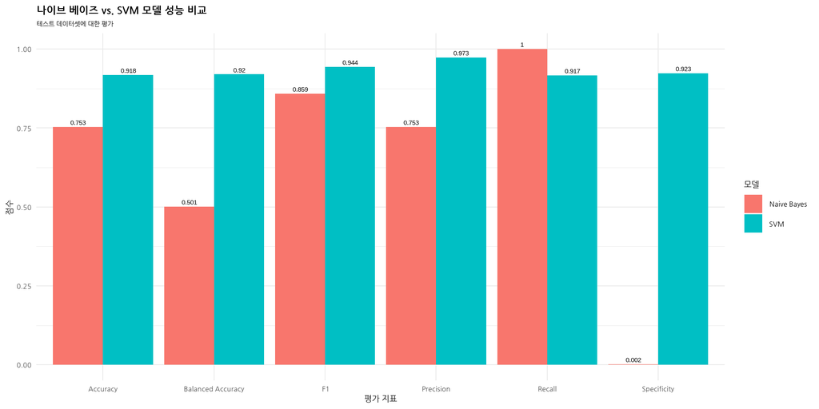

```r
# ggplot2를 이용한 막대 그래프 생성
# ggplot() 함수로 시각화의 기본 틀을 설정함.
# aes(x = Metric, y = Value, fill = Model): x축에 평가지표(Metric), y축에 값(Value), 막대의 색상을 모델(Model)에 따라 다르게 매핑함.
comparison_data %>%
  ggplot(aes(x = Metric, y = Value, fill = Model)) +

  # 막대 그래프 레이어 추가
  # geom_bar()로 막대를 그림.
  # stat = "identity": y축의 값을 막대의 높이로 그대로 사용함.
  # position = position_dodge(): 같은 Metric에 대한 두 모델의 막대를 겹치지 않고 옆으로 나란히 배치함.
  geom_bar(stat = "identity", position = position_dodge()) +

  # 막대 위에 텍스트 레이블 추가
  # geom_text()로 막대 위에 수치 값을 표시함.
  # aes(label = round(Value, 3)): 표시할 텍스트는 Value를 소수점 3자리까지 반올림한 값임.
  # vjust = -0.5: 텍스트의 수직 위치를 막대 위로 살짝 올림.
  # position = position_dodge(0.9): 텍스트 위치를 막대 위치에 맞게 옆으로 조정함.
  # size = 4: 텍스트 크기를 설정함.
  geom_text(aes(label = round(Value, 3)), vjust = -0.5, position = position_dodge(0.9), size = 4) +

  # 축 및 제목 레이블 설정
  # labs() 함수로 그래프의 제목, 부제, x축/y축 이름 등을 설정함.
  labs(
    title = "나이브 베이즈 vs. SVM 모델 성능 비교",
    subtitle = "테스트 데이터셋에 대한 평가",
    x = "평가 지표",
    y = "점수",
    fill = "모델"
  ) +

  # y축 범위 설정
  # ylim()으로 y축의 범위를 0에서 1까지로 고정하여 비율을 명확하게 보여줌.
  ylim(0, 1) +

  # 그래프 테마 적용
  # theme_minimal()로 깔끔한 배경의 테마를 적용함.
  # theme() 함수로 글자 크기 등 세부적인 디자인 요소를 조정함.
  theme_minimal() +
  theme(
    text = element_text(family = "nanumgothic"), # 그래프의 모든 텍스트에 나눔고딕 폰트 적용
    plot.title = element_text(size = 18, face = "bold"),
    axis.title = element_text(size = 14),
    axis.text = element_text(size = 12),
    legend.title = element_text(size = 14),
    legend.text = element_text(size = 12)
  )
```

## (7) 혼동행렬 시각화

### 1) 나이브 베이즈 혼동행렬 시각화

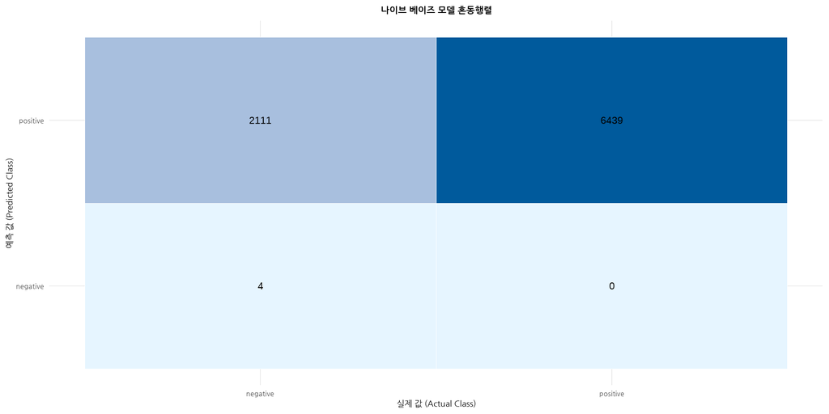

```r
# confusionMatrix 객체에서 table(표) 부분을 데이터프레임으로 변환
# ggplot2로 시각화하기 위해 table 객체를 Prediction, Reference, Freq 열을 가진 데이터프레임으로 변환하기.
nb_cm_df <- as.data.frame(nb_cm$table)

# ggplot2를 사용하여 혼동행렬을 히트맵(Heatmap) 형태로 시각화
# ggplot() 함수로 시각화의 기본 틀을 설정함.
# aes() 안에서 x축은 실제값(Reference), y축은 예측값(Prediction), fill은 빈도(Freq)에 매핑함.
nb_cm_df %>%
  ggplot(aes(x = Reference, y = Prediction, fill = Freq)) +

  # 타일(사각형) 레이어 추가
  # geom_tile()은 각 셀을 색상으로 채우는 히트맵을 생성함.
  # colour = "white"는 각 타일 사이에 흰색 테두리를 추가하여 구분을 명확히 함.
  geom_tile(colour = "white") +

  # 색상 그라데이션 설정
  # scale_fill_gradient()는 빈도(Freq) 값에 따라 색상의 진하기를 조절함.
  # low는 낮은 값의 색상, high는 높은 값의 색상을 의미.
  scale_fill_gradient(low = "#e6f5ff", high = "#005a9c") +

  # 타일 위에 텍스트 레이블 추가
  # geom_text()는 각 타일 위에 실제 빈도 수를 텍스트로 표시함.
  # aes(label = Freq): 표시할 텍스트로 Freq 열의 값을 사용함.
  # size = 6: 텍스트의 크기를 설정함.
  geom_text(aes(label = Freq), size = 6) +

  # 축 및 제목 레이블 설정
  # labs() 함수로 그래프의 제목과 축 이름을 설정함.
  labs(
    title = "나이브 베이즈 모델 혼동행렬",
    x = "실제 값 (Actual Class)",
    y = "예측 값 (Predicted Class)",
    fill = "빈도"
  ) +

  # 그래프 테마 및 세부 디자인 조정
  # theme_minimal()로 깔끔한 테마를 적용함.
  # theme() 함수로 글자 크기, 축 텍스트 각도 등을 조정하여 가독성을 높임.
  theme_minimal() +
  theme(
    text = element_text(family = "nanumgothic"), # 그래프의 모든 텍스트에 나눔고딕 폰트 적용
    plot.title = element_text(size = 16, face = "bold", hjust = 0.5), # 제목을 가운데 정렬함.
    axis.title = element_text(size = 14),
    axis.text = element_text(size = 12),
    legend.position = "none" # 범례는 불필요하므로 제거함.
  )
```

### 2) 서포트 벡터 머신 혼동행렬 시각화

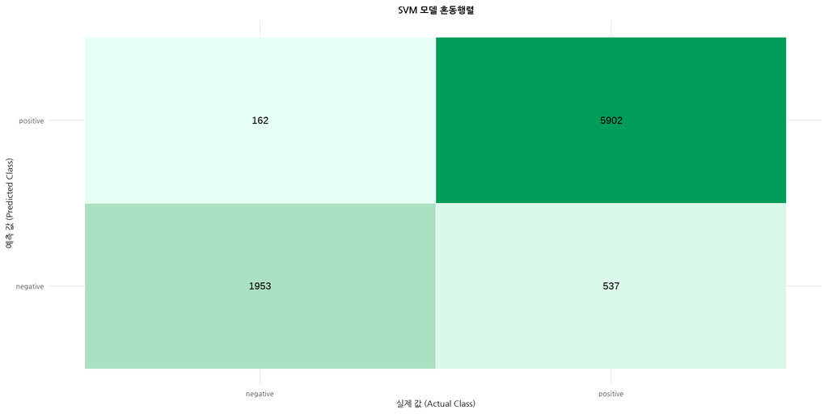

```r
# SVM의 confusionMatrix 객체에서 table 부분을 데이터프레임으로 변환
# 나이브 베이즈와 동일한 방식으로, ggplot2 시각화를 위해 table 객체를 데이터프레임으로 만듦.
svm_cm_df <- as.data.frame(svm_cm$table)

# ggplot2 패키지를 사용하여 SVM의 혼동행렬을 히트맵 형태로 시각화
# ggplot() 함수로 시각화의 기본 틀을 설정하고, x축, y축, 채우기 색상을 매핑함.
svm_cm_df %>%
  ggplot(aes(x = Reference, y = Prediction, fill = Freq)) +

  # 타일(사각형) 레이어 추가
  # geom_tile()로 각 셀(실제값-예측값 조합)을 사각형으로 그림.
  geom_tile(colour = "white") +

  # 색상 그라데이션 설정 (나이브 베이즈와 다른 색상 사용)
  # scale_fill_gradient()로 색상을 설정하되, 시각적 구분을 위해 녹색 계열을 사용함.
  scale_fill_gradient(low = "#e6fff5", high = "#009c5a") +

  # 타일 위에 텍스트 레이블 추가
  # geom_text()로 각 타일의 중앙에 빈도 수(Freq)를 표시함.
  geom_text(aes(label = Freq), size = 6) +

  # 축 및 제목 레이블 설정
  # labs() 함수로 그래프의 제목과 축 이름을 명확하게 지정함.
  labs(
    title = "SVM 모델 혼동행렬",
    x = "실제 값 (Actual Class)",
    y = "예측 값 (Predicted Class)",
    fill = "빈도"
  ) +

  # 그래프 테마 및 세부 디자인 조정
  # theme_minimal()과 theme()을 사용하여 그래프를 깔끔하게 만듦.
  theme_minimal() +
  theme(
    text = element_text(family = "nanumgothic"), # 그래프의 모든 텍스트에 나눔고딕 폰트 적용.
    plot.title = element_text(size = 16, face = "bold", hjust = 0.5),
    axis.title = element_text(size = 14),
    axis.text = element_text(size = 12),
    legend.position = "none" # 범례를 제거함.
  )
```

[^1]: ROC(Receiver Operating Characteristic) 곡선은 이진분류 모델의 판별성능을 임계값(threshold)을 변화시키며 평가하는 그래프임. 곡선은 모델의 민감도(True Positive Rate, TPR)와 1−특이도(False Positive Rate, FPR)를 서로 대응시켜 보여줌. 세로축은 TPR(=재현율, 실제 Positive 중 모델이 Positive로 맞춘 비율)을 나타내고 가로축은 FPR(=거짓 Positive 비율, 실제 음성 중 모델이 Positive로 잘못 분류한 비율)을 나타낸다. 모델의 출력([EX] 확률)을 높은 값부터 낮은 값으로 임계값을 옮기면 TPR과 FPR이 함께 변화하며 ROC 곡선이 그려짐. ROC 곡선 아래 면적인 AUC(area under the curve)는 모델의 전체적인 분류능력을 0에서 1 사이의 값으로 요약함. AUC가 1에 가까울수록 양성과 음성을 잘 구분하는 모델임을 의미하고, 0.5는 무작위 추측과 동일한 성능을 의미함.
[^2]: 조화평균은 여러 값을 합쳐 하나의 대표값을 만들 때 사용하는 방법으로, 큰 값보다 작은 값에 더 민감하게 반응하는 평균이다. 두 값(a, b)의 조화평균의 수식은 $H(a,b) = \frac{2ab}{a + b}$임. 값을 역수로 바꿔 산술평균을 구한 뒤 다시 역수로 돌려오는 방식이라서, 어느 한 쪽 값이 작으면 전체 평균도 빠르게 낮아짐. F1은 정밀도와 재현율을 모두 중요하게 고려하려는 지표임. 정밀도나 재현율 중 하나가 매우 낮으면 실제 성능에 큰 문제가 생기므로, 두 값의 단순한 산술평균은 한쪽이 낮아도 다른 쪽이 높으면 가려질 수 있음. 조화평균은 낮은 쪽의 값을 강하게 반영하여, 둘 사이 불균형을 벌려진 결과가 되지 않도록 함. 가령, 정확도 = 0.9, 재현율 = 0.1 일 때, 산술평균 = 0.5이지만 조화평균 =(2 * 0.9 * 0.1)/(0.9 + 0.1) ≈ 0.18임. 즉 높은 정확도 하나로 전체 성능이 좋아 보이는 현상을 조화평균이 막아줌.